# DRIFTS Analysis for Soil Samples

Adrianne Seiden

2026-08-05

# Overview

This document imports and analyzes FTIR DRIFTS data from DPT files, normalizes & plots the spectra, calculates functional group proportions, and visualizes the results. It knits to an HTML document, saved in my GitHub repository. The general analysis pipeline is based on methods from Mainka et al. (2022), with modifications to fit the Salk project variables (crop type and decomposition time).

Mainka, M., Summerauer, L., Wasner, D., Garland, G., Griepentrog, M., Berhe, A. A., & Doetterl, S. (2022). Soil geochemistry as a driver of soil organic matter composition: Insights from a soil chronosequence. Biogeosciences, 19(6), 1675–1689. https://doi.org/10.5194/bg-19-1675-2022

## Statistical Methods

### 2. **Spectral Integration for Functional Groups**

Functional group proportions are calculated using integrated peak areas from specific spectral regions (based on Mainka et al. 2022): - Peak areas are calculated using the **trapezoidal rule** (via the `pracma::trapz()` function) across four spectral windows: - **Simple plant (aliphatic)**: 2839–2870 cm⁻¹ + 2898–2976 cm⁻¹ - **Complex plant (aromatic)**: 1500–1550 cm⁻¹ - **Microbial**: 1580–1660 cm⁻¹

- **Proportion calculation**: Each functional group’s proportion is calculated as:
  $$\text{Proportion} = \frac{\text{Peak
  Area}_{\text{functional group}}}{\text{Total Peak Area}_{\text{all
  groups}}}$$
- **Ratio metrics** are derived from these proportions (e.g., Simple:Complex-plant ratio, Total Plant:Microbial ratio)

### 3. **Descriptive Statistics by Group**

Summary statistics are calculated by crop and timepoint: - **Mean** and **Standard Error (SE)** for each functional group proportion
$$SE =
\frac{SD}{\sqrt{n}}$$
where SD is the standard deviation and n is the sample size for each group

### 4. **Linear Regression Analysis (Ratio Scatterplots)**

Time-series trends are analyzed using **simple linear regression** for each crop, fitting all individual data points (not just group averages): - **Model**: `y ~ timepoint_numeric` where y is a ratio metric (e.g., Simple:Microbial) - **Statistics reported**: - **R²** (coefficient of determination): Explains the proportion of variance in the ratio accounted for by timepoint - **Slope**: The change in ratio per week, fitted to all individual replicate measurements - **P-value**: Statistical significance test (α = 0.05); values < 0.05 marked with asterisk

This approach uses all available replicate data for regression rather than averaged values, providing more robust statistical inference.

### 5. **Data Visualization**

- **Ridge plots**: Use transparent ribbons to show the full range of spectral data (min to max across samples from the same crop and timepoint), with overlaid opaque lines showing the mean intensity. Annotations indicate the spectral regions used for functional group integration.
- **Stacked bar plots**: Display functional group proportions by crop over time, with labels indicating the proportion represented by each functional group as a percentage of the total integrated area.
- **Ratio scatterplots**: Display averaged ratios with error bars, overlaid with fitted regression lines and statistics (based on all individual data points).

### 6. **Data Aggregation Levels**

- Timepoint-level summaries (across all crops)
- Crop-level summaries (across all timepoints)
- Crop × Timepoint summaries (group means and SEs)

All statistical calculations are implemented in R using `dplyr` for data manipulation, `ggplot2` for visualization, and base R functions for statistical modeling.

# Setting up

This section sets up the environment, loads required libraries, and defines paths to data and output directories. It also includes a helper function to find the most recent processed integration data file, so that the code does not need to re-analyze dpt files that have already been processed every time it is run.

**YOU WILL NEED TO CHANGE THE PATHS BELOW TO MATCH YOUR SYSTEM.** 1. Create a folder for the outputs if it does not already exist. The code will save the processed integration data and plots to this folder. 2. Copy and paste the full path to the folder containing the DPT files into the `dpt_folder` variable (change “" to”/” if you are on Windows; delete “file.path(box_base,” if not using Box). The code will read all DPT files in that folder and process them. 3. Copy and paste the full path to the folder where you want to save outputs into the `outputs_folder` variable (change “" to”/” if you are on Windows; delete “file.path(box_base,” if not using Box). The code will save all outputs to that folder.

# Preparing data for analysis

## Importing DPT data

```r
# Check if folder exists and list files
if (!dir.exists(dpt_folder)) {
  stop("Directory does not exist: ", dpt_folder)
}

# List and sort files
cat("Files found in directory:\n")
```

```
## Files found in directory:
```

```r
print(list.files(dpt_folder))
```

```
##  [1] "DRIFTS_Pot001_13Cwheat_wk0_rhizoSoil_260618.0.dpt"
##  [2] "DRIFTS_Pot012_13Csoy_wk10_rhizoSoil_260624.0.dpt"
##  [3] "DRIFTS_Pot020_12CnoPlant_wk30_rhizoSoil_260617.0.dpt"
##  [4] "DRIFTS_Pot020_12CnoPlant_wk40_rhizoSoil_260617.0.dpt"
##  [5] "DRIFTS_Pot024_13Cwheat_wk0_rhizoSoil_260618.0.dpt"
##  [6] "DRIFTS_Pot028_13Cwheat_wk0_rhizoSoil_260618A.0.dpt"
##  [7] "DRIFTS_Pot028_13Cwheat_wk0_rhizoSoil_260618B.0.dpt"
##  [8] "DRIFTS_Pot029_13Cwheat_wk10_rhizoSoil_260624.0.dpt"
##  [9] "DRIFTS_Pot029_13Cwheat_wk40_rhizoSoil_260702.0.dpt"
## [10] "DRIFTS_Pot030_13Csoy_wk40_rhizoSoil_260702.0.dpt"
## [11] "DRIFTS_Pot032_13Cwheat_wk0_rhizoSoil_260618.0.dpt"
## [12] "DRIFTS_Pot044_13CnoPlant_wk0_bulkSoil_260617.0.dpt"
## [13] "DRIFTS_Pot044_13CnoPlant_wk10_rhizoSoil_260617.0.dpt"
## [14] "DRIFTS_Pot044_13CnoPlant_wk40_rhizoSoil_260617.0.dpt"
## [15] "DRIFTS_Pot050_13Csoy_wk0_rhizoSoil_260618.0.dpt"
```

[output cut: 34 more lines]

```r
DPTfiles <- sort(list.files(dpt_folder, pattern = ".dpt"))
cat("Number of .dpt files:", length(DPTfiles), "\n")
```

```
## Number of .dpt files: 49
```

```r
# Read files individually and combine
dpt_data_list <- list()

for (i in seq_along(DPTfiles)) {
  file_path <- file.path(dpt_folder, DPTfiles[i])

  # Read as lines and parse manually (DPT files are space-delimited)
  lines <- readLines(file_path, warn = FALSE)
  lines <- lines[lines != ""]  # Remove empty lines

  # Split each line by whitespace
  split_lines <- strsplit(lines, "\\s+")

  # Convert to data frame
  temp_data <- tryCatch({
    data.frame(
      wavenumber = as.numeric(sapply(split_lines, `[`, 1)),
      absorbance = as.numeric(sapply(split_lines, `[`, 2)),
      stringsAsFactors = FALSE
    )
  }, error = function(e) NULL)

  if (!is.null(temp_data)) {
    # Add filename column
    temp_data$filename <- DPTfiles[i]

    # Store in list
    dpt_data_list[[i]] <- temp_data
  }
}

# Remove NULL entries (failed reads)
dpt_data_list <- dpt_data_list[!sapply(dpt_data_list, is.null)]

# Combine all data
dpt_data <- bind_rows(dpt_data_list)

# Remove any rows with NA values
dpt_data <- dpt_data[complete.cases(dpt_data), ]

# Extract metadata from filenames
dpt_data <- dpt_data %>%
  mutate(
    crop = case_when(
      str_detect(filename, "noPlant") ~ "noPlant",
      str_detect(filename, "wheat") ~ "wheat",
      str_detect(filename, "rice") ~ "rice",
      str_detect(filename, "soy") ~ "soy",
      TRUE ~ NA_character_
    ),
    timepoint = str_extract(filename, "wk\\d+"),
    sample_type = case_when(
      str_detect(filename, "root") ~ "root",
      str_detect(filename, "rhizoSoil") ~ "rhizoSoil",
      str_detect(filename, "bulkSoil") ~ "bulkSoil",
      TRUE ~ NA_character_
    ),
    # Extract ID (pot number) from filename
ID = case_when(
      str_detect(filename, regex("pot[0-9]+", ignore_case = TRUE)) ~
        str_extract(filename, regex("pot[0-9]+", ignore_case = TRUE)) %>%
        str_remove(regex("pot", ignore_case = TRUE)) %>%
        str_pad(width = 3, pad = "0"),
      # Alternative pattern for files without 'pot' prefix
      str_detect(filename, regex("DRIFTS_[0-9]+", ignore_case = TRUE)) ~ str_extract(filename, regex("DRIFTS_[0-9]+", ignore_case = TRUE)) %>%
                                              str_remove(regex("DRIFTS_", ignore_case = TRUE)) %>%
                                              str_pad(width = 3, pad = "0"),
      TRUE ~ NA_character_
    )
  ) %>%
  # Correct sample_type mislabeling: for the noPlant (control) pots, rhizosphere-equivalent
  # soil (soil aggregated on leftover root fragments from the original field soil, not from
  # a crop grown in this experiment) was only picked out starting at the week 30 sampling
  # point. The wk10 noPlant files were recorded as "rhizoSoil" but predate that protocol
  # change, so they're reclassified here as bulk soil to match how they were actually collected.
  mutate(
    sample_type = if_else(crop == "noPlant" & timepoint == "wk10" & sample_type == "rhizoSoil",
                           "bulkSoil", sample_type)
  ) %>%
  filter(!is.na(sample_type)) %>%  # Remove files without clear sample type
  filter(!str_detect(filename, "KBr")) %>%  # Remove KBr files if needed
  # Filter out anomalous spectra if needed
  filter(!filename %in% c("DRIFTS_Pot109_13Cwheat_wk10_rhizoSoil_260624a.0.dpt",
                          "DRIFTS_pot047_13Crice_wk0_root_250725.0.dpt",
                          "DRIFTS_Pot072_12CnoPlant_wk40_rhizoSoil_260617.0.dpt",
                          "DRIFTS_Pot094_13Csoy_wk10_rhizoSoil_260624A.0.dpt"))
# save as csv for record-keeping
write.csv(dpt_data, file.path(outputs_folder, "dpt_data.csv"), row.names = FALSE)
```

## Normalizing data

This code is modified to use baseline correction (subtracting the minimum) and standard normal variate (SNV) normalization.

```r
# Normalize absorbance data by sample (same approach as OPUSprocessing.Rmd)
dpt_data <- dpt_data %>%
  group_by(filename) %>%
  mutate(
    # Baseline correction - subtract minimum
    baseline_corrected = absorbance - min(absorbance, na.rm = TRUE),
    # Apply SNV (Standard Normal Variate) normalization
    mean_abs = mean(baseline_corrected, na.rm = TRUE),
    sd_abs = sd(baseline_corrected, na.rm = TRUE),
    normalized_absorbance = (baseline_corrected - mean_abs) / sd_abs
  ) %>%
  select(-mean_abs, -sd_abs) %>%
  ungroup()
dpt_data <- dpt_data %>%
  group_by(filename) %>%
  mutate(
    # Baseline correction - subtract minimum
    snv_corrected = normalized_absorbance - min(normalized_absorbance, na.rm = TRUE)
  ) %>%
  ungroup()

dpt_data <- dpt_data %>%
  group_by(filename) %>%
  mutate(
    # Baseline correction + 1
    snv_plusOne = normalized_absorbance + 1
  ) %>%
  ungroup()

## Save normalized data for record-keeping

write.csv(dpt_data, file.path(outputs_folder, "dpt_data_normalized.csv"), row.names = FALSE)
```

# Plotting DRIFTS spectra

## Plotting by timepoint

### Ridge plots

These plots are of normalized absorbance values. The thickness of the opaque line represents the range of the data. Annotations indicate integration regions used for calculations of simple plant, complex plant, and microbial organic matter proportions. Integration regions according to Mainka et al. (2022):

Mainka, M., Summerauer, L., Wasner, D., Garland, G., Griepentrog, M., Berhe, A. A., & Doetterl, S. (2022). Soil geochemistry as a driver of soil organic matter composition: Insights from a soil chronosequence. Biogeosciences, 19(6), 1675–1689. https://doi.org/10.5194/bg-19-1675-2022

| Simple plant (aliphatic): | 2976 - 2898 cm<sup>-1</sup> + 2870 - 2839 cm<sup>-1</sup> |
| --- | --- |
| Microbial: | 1660 - 1580 cm<sup>-1</sup> |
| Complex plant (aromatic): | 1550 - 1500 cm<sup>-1</sup> |

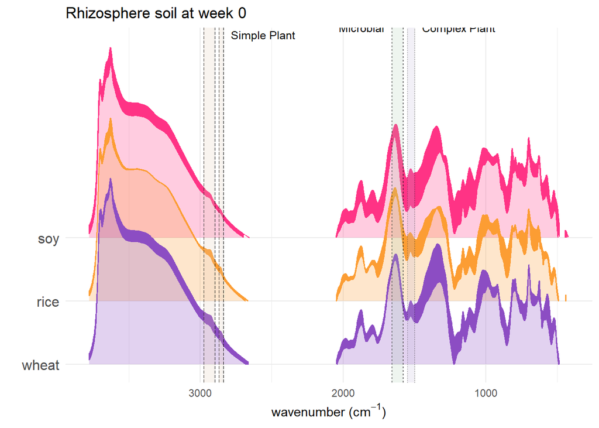

| Week 0 samples |
| --- |
| 5 wheat |
| 3 rice |
| 3 soy |

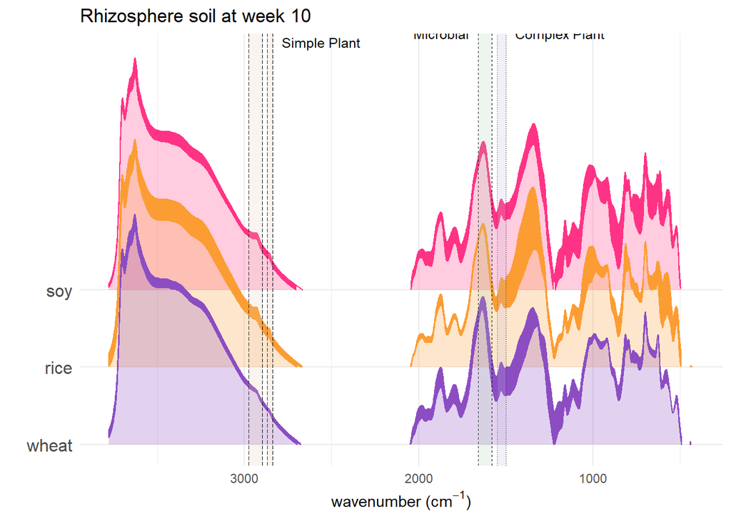

| Week 10 samples |
| --- |
| 3 wheat |
| 5 rice |
| 3 soy |

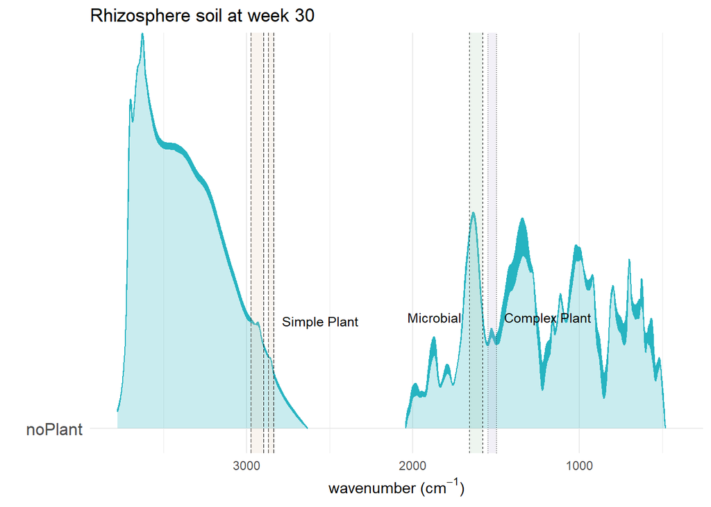

| Week 30 samples |
| --- |
| 2 noPlant |

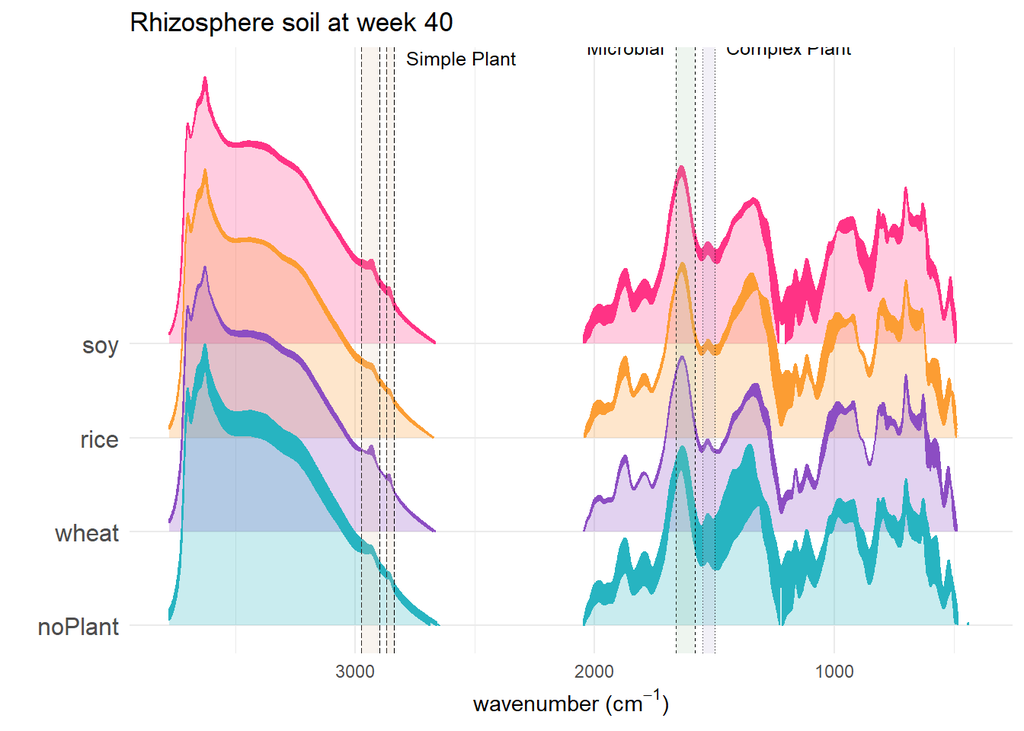

| Week 40 samples |
| --- |
| 6 noPlant |
| 3 wheat |
| 3 rice |
| 3 soy |

```r
# Filter for rhizoSoil samples only
dpt_data_rhizo <- dpt_data %>%
  filter(sample_type == "rhizoSoil") %>%
  filter(!is.na(crop))

# Generic function to create ridge plots for any timepoint
create_timepoint_ridge_plot <- function(data, timepoint_week, title = NULL) {
  # Filter data for specific timepoint
  filtered_data <- data %>%
    filter(timepoint == timepoint_week) %>%
    mutate(crop = factor(crop, levels = c("noPlant", "wheat", "rice", "soy")))

  # Create title if not provided
  if (is.null(title)) {
    week_num <- str_extract(timepoint_week, "\\d+")
    title <- paste("Rhizosphere soil at week", week_num)
  }

  # Determine y-position for annotations based on data
  present_levels <- levels(droplevels(filtered_data$crop))  # only levels actually in this week's data, in original order
  peak_heights <- filtered_data %>%
    group_by(crop) %>%
    summarise(group_max = max(snv_plusOne, na.rm = TRUE)) %>%
    mutate(baseline = match(as.character(crop), present_levels))  # true rendered position, not raw factor code
  global_max <- max(peak_heights$group_max, na.rm = TRUE)
  max_y <- max(peak_heights$baseline + 3 * (peak_heights$group_max / global_max)) + 0.2
#   n_groups <- length(unique(filtered_data$crop))
#   ridge_scale <- 3  # matches your geom_density_ridges(scale = 3)
#   max_y <- n_groups + ridge_scale * .33 + 0.33  # headroom above the top category



  # Create the plot
  ridge_plot <- filtered_data %>%
    ggplot(mapping = aes(x = wavenumber,
                         y = crop,
                         height = snv_plusOne,
                         group = crop,
                         fill = crop,
                         color = crop)) +
    geom_density_ridges(stat = "identity",
                        scale = 3, # overlap scale - 1 is no overlap, >1 is more overlap
                        alpha = 0.25) +
    geom_vline(xintercept = 1500, linetype = "dotted", linewidth = 0.23) +
    geom_vline(xintercept = 1550, linetype = "dotted", linewidth = 0.23) +
    geom_vline(xintercept = 1580, linetype = "dashed", linewidth = 0.23) +
    geom_vline(xintercept = 1660, linetype = "dashed", linewidth = 0.23) +
    geom_vline(xintercept = 2839, linetype = "longdash", linewidth = 0.23) +
    geom_vline(xintercept = 2870, linetype = "longdash", linewidth = 0.23) +
    geom_vline(xintercept = 2898, linetype = "longdash", linewidth = 0.23) +
    geom_vline(xintercept = 2976, linetype = "longdash", linewidth = 0.23) +
    xlim(3777, 422) +
    scale_y_discrete(expand = expansion(mult = c(0, 0.1), add = c(0, 0))) +  # space below, space above+  # space below, space above

    theme(axis.text.y = element_text(size = 12),
          legend.position = "none") +
    scale_fill_manual(values = crop_colors, labels = crop_labels) +
    scale_color_manual(values = crop_colors, labels = crop_labels) +
    ggtitle(title) +
    labs(x = expression("wavenumber (cm"^-1*")"), y = "") +
    # Add simple plant region annotation
    annotate("rect", xmin = 2976, xmax = 2898, ymin = -Inf, ymax = Inf,
             alpha = 0.2, fill = "#e3c8b1") +
    annotate("rect", xmin = 2870, xmax = 2839, ymin = -Inf, ymax = Inf,
             alpha = 0.2, fill = "#e3c8b1") +
    annotate("text", x = 2560, y = max_y, label = "Simple Plant",
             size = 3.3, hjust = 0.5, color = annotation_text_color) +
    # Add microbial region annotation
    annotate("rect", xmin = 1660, xmax = 1580, ymin = -Inf, ymax = Inf,
             alpha = 0.2, fill = "#a8cbad") +
    annotate("text", x = 1870, y = max_y + 0.11, label = "Microbial",
             size = 3.3, hjust = 0.5, color = annotation_text_color) +
    # Add complex plant region annotation
    annotate("rect", xmin = 1550, xmax = 1500, ymin = -Inf, ymax = Inf,
             alpha = 0.2, fill = "#beb5d5") +
    annotate("text", x = 1190, y = max_y + 0.11, label = "Complex Plant",
             size = 3.3, hjust = 0.5, color = annotation_text_color)

  return(list(plot = ridge_plot, data = filtered_data))
}

# Generic function to create sample count tables
create_sample_count_table <- function(filtered_data, timepoint_week) {
  week_num <- str_extract(timepoint_week, "\\d+")
  col_name <- paste("Week", week_num, "samples")

  counts <- filtered_data %>%
    select(filename, crop) %>%
    distinct() %>%
    count(crop) %>%
    arrange(match(crop, c("noPlant", "wheat", "rice", "soy"))) %>%
    mutate(!!col_name := paste(n, "&nbsp;&nbsp;", crop)) %>%
    select(all_of(col_name))

  return(counts)
}

# Create plots and tables for each timepoint
timepoints <- sort(unique(dpt_data_rhizo$timepoint))

for (tp in timepoints) {
  # Create plot and get filtered data
  result <- create_timepoint_ridge_plot(dpt_data_rhizo, tp)

  # Print the plot
  print(result$plot)

  # Create and print sample count table with results='asis'
  counts_table <- create_sample_count_table(result$data, tp)
  cat(knitr::kable(counts_table, format = "html", escape = FALSE))
  cat("<br><br>")  # Add HTML line breaks for spacing
}
```

## Plotting by crop

These plots are of normalized absorbance values. The thickness of the opaque line represents the range of the data. Annotations indicate integration regions used for calculations of simple plant, complex plant, and microbial organic matter proportions.

| Simple plant (aliphatic): | 2976 - 2898 cm<sup>-1</sup> + 2870 - 2839 cm<sup>-1</sup> |
| --- | --- |
| Microbial: | 1660 - 1580 cm<sup>-1</sup> |
| Complex plant (aromatic): | 1550 - 1500 cm<sup>-1</sup> |

### Ridge plots

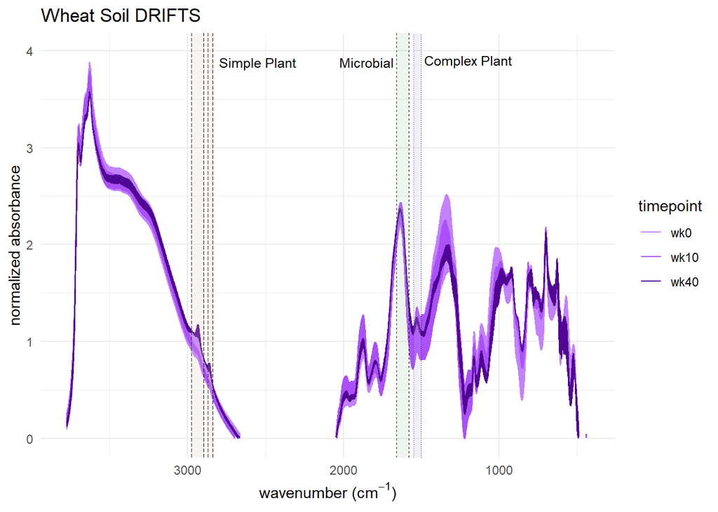

```r
# Define crop-specific color palettes
crop_timepoint_colors <- color_map_all_sep


# Generic function to create crop-specific DRIFTS plots
create_crop_plot <- function(data, crop_name, color_palette) {
  # Filter data for specific crop
  crop_data <- data %>%
    group_by(timepoint) %>%
    filter(crop == crop_name)

  # Ensure absorbance is numeric
  crop_data$snv_plusOne <- as.numeric(crop_data$snv_plusOne)

  # Create the plot
  crop_plot <- ggplot(crop_data,
                      aes(x = wavenumber,
                          y = snv_plusOne,
                          color = timepoint)) +
    xlim(3777, 422) +
    ylim(0, max(crop_data$snv_plusOne, na.rm = TRUE) + 0.1) +
    geom_line() +

    scale_color_manual(values = color_palette) +
    ggtitle(paste(str_to_title(crop_name), "Soil DRIFTS")) +
    labs(x = expression("wavenumber (cm"^-1*")"),
         y = "normalized absorbance") +
    geom_vline(xintercept = 1500, linetype = "dotted", linewidth = 0.3) +
    geom_vline(xintercept = 1550, linetype = "dotted", linewidth = 0.3) +
    geom_vline(xintercept = 1580, linetype = "dashed", linewidth = 0.23) +
    geom_vline(xintercept = 1660, linetype = "dashed", linewidth = 0.23) +
    geom_vline(xintercept = 2839, linetype = "longdash", linewidth = 0.23) +
    geom_vline(xintercept = 2870, linetype = "longdash", linewidth = 0.23) +
    geom_vline(xintercept = 2898, linetype = "longdash", linewidth = 0.23) +
    geom_vline(xintercept = 2976, linetype = "longdash", linewidth = 0.23) +
    # Add simple plant region annotation
    annotate("rect", xmin = 2976, xmax = 2898, ymin = -Inf, ymax = Inf,
             alpha = 0.2, fill = "#e3c8b1") +
    annotate("rect", xmin = 2870, xmax = 2839, ymin = -Inf, ymax = Inf,
             alpha = 0.2, fill = "#e3c8b1") +
    annotate("text", x = 2550, y = max(crop_data$snv_plusOne), label = "Simple Plant",
             size = 3.3, hjust = 0.5, color = annotation_text_color) +
    # Add microbial region annotation
    annotate("rect", xmin = 1660, xmax = 1580, ymin = -Inf, ymax = Inf,
             alpha = 0.2, fill = "#a8cbad") +
    annotate("text", x = 1850, y = max(crop_data$snv_plusOne), label = "Microbial",
             size = 3.3, hjust = 0.5, color = annotation_text_color) +
    # Add complex plant region annotation
    annotate("rect", xmin = 1550, xmax = 1500, ymin = -Inf, ymax = Inf,
             alpha = 0.2, fill = "#beb5d5") +
    annotate("text", x = 1200, y = max(crop_data$snv_plusOne)+0.02, label = "Complex Plant",
             size = 3.3, hjust = 0.5, color = annotation_text_color)

  return(list(plot = crop_plot, data = crop_data))
}

# Generic function to create crop ID tables
create_crop_id_table <- function(crop_data, crop_name) {
  combinations <- crop_data %>%
    select(ID, timepoint) %>%
    distinct() %>%
    arrange(ID, timepoint) %>%
    group_by(timepoint) %>%
    summarise(pot_ids = {
      ids <- paste(ID, sep = "")
      # Group every 3 items and join with line breaks
      grouped <- split(ids, ceiling(seq_along(ids)/5))
      lines <- sapply(grouped, function(x) paste(x, collapse = ",&ensp;"))
      paste(lines, collapse = "<br>")
    }, .groups = 'drop') %>%
    pivot_wider(names_from = timepoint, values_from = pot_ids)

  return(combinations)
}

# Generate plots and tables for each crop
crops <- c("wheat", "rice", "soy", "noPlant")

for (crop in crops) {
  # Create plot and get data
  result <- create_crop_plot(dpt_data_rhizo, crop, crop_timepoint_colors[[crop]])

  # Print the plot
  print(result$plot)
  cat("<br>")  # Add space between plot and table

  # Create and print ID combinations table
  id_table <- create_crop_id_table(result$data, crop)
  cat(paste0("<h4>", str_to_title(crop), " rhizosphere soil samples</h4>"))
  cat(knitr::kable(id_table, format = "html", escape = FALSE, table.attr = 'style="border-collapse: separate; border-spacing: 35px 0;"'))
  cat("<br><br>")  # Add HTML line breaks for spacing
}
```

#### Wheat rhizosphere soil samples

| wk0 | wk10 | wk40 |
| --- | --- | --- |
| 001, 024, 028, 032 | 029, 053, 109 | 029, 053, 109 |

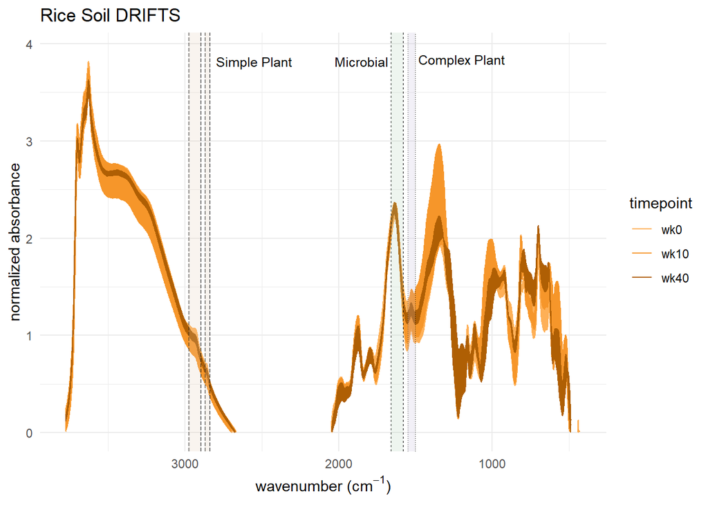

#### Rice rhizosphere soil samples

| wk0 | wk10 | wk40 |
| --- | --- | --- |
| 071, 103 | 055, 087, 119 | 055, 087, 119 |

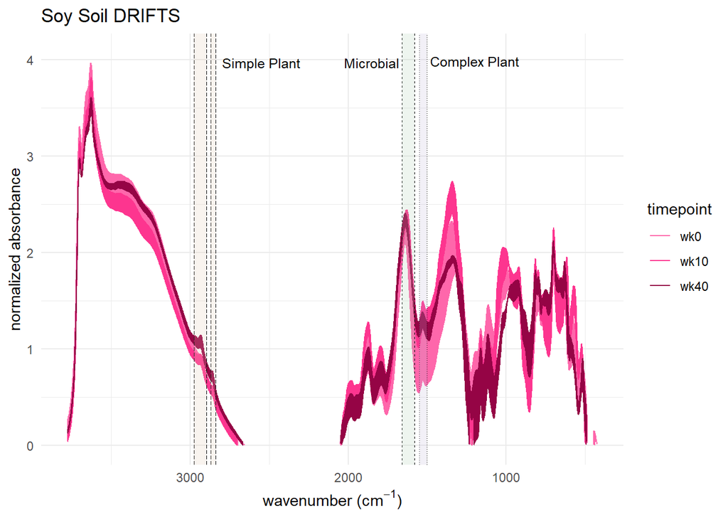

#### Soy rhizosphere soil samples

| wk0 | wk10 | wk40 |
| --- | --- | --- |
| 050, 062, 104 | 012, 080, 094 | 030, 080, 094 |

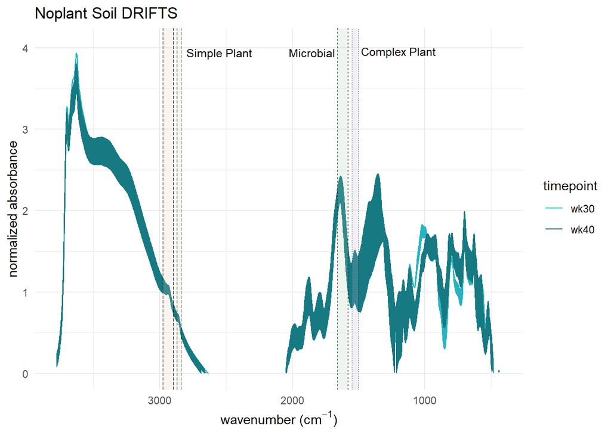

#### Noplant rhizosphere soil samples

| wk30 | wk40 |
| --- | --- |
| 020, 052 | 020, 044, 052, 064, 091 108 |

## Comparing bulk vs rhizosphere soil (no-plant control)

For the no-plant control pots, “rhizosphere” soil refers to soil aggregated on leftover root fragments from the original field soil (not from a crop grown in this experiment). Those fragments and their associated soil were only picked out starting at the week 30 sampling point, so no-plant rhizosphere soil is only available for wk30 and wk40, while no-plant bulk soil is only available for wk0 and wk10. The comparison below pools all no-plant bulk soil samples against all no-plant rhizosphere soil samples regardless of timepoint, since the root fragments were not fresh and there’s no way to know how long they had been decomposing before the experiment started.

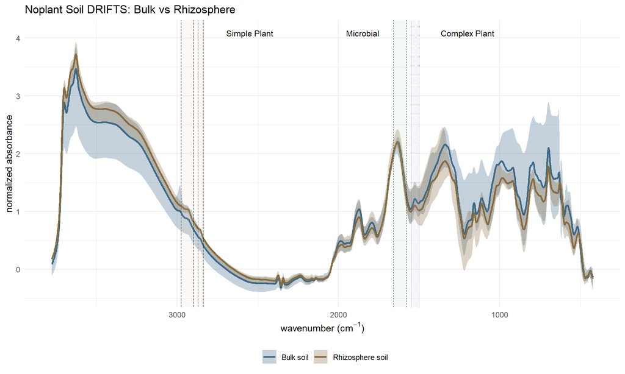

```r
# Helper: count unique samples (filenames), grouped by crop, timepoint & sample_type.
# Reused by every spectral figure from here forward.
count_samples_by_group <- function(data) {
  data %>%
    distinct(filename, crop, timepoint, sample_type) %>%
    count(crop, timepoint, sample_type, name = "n_samples") %>%
    mutate(crop = factor(crop, levels = c("noPlant", "wheat", "rice", "soy"))) %>%
    arrange(crop, timepoint, sample_type)
}

# Pull ALL noPlant samples (bulk + rhizosphere), not just the rhizoSoil-filtered subset
# used for the crop-timepoint plots above
noplant_bulk_vs_rhizo <- dpt_data %>%
  filter(crop == "noPlant", sample_type %in% c("bulkSoil", "rhizoSoil")) %>%
  mutate(
    snv_plusOne = as.numeric(snv_plusOne),
    sample_type_label = if_else(sample_type == "bulkSoil", "Bulk soil", "Rhizosphere soil")
  )

bulk_rhizo_colors <- c("Bulk soil" = "#3D6988", "Rhizosphere soil" = "#876B3D")

# Average + range ribbon for each sample type, pooled across whichever timepoints are
# available for that sample type (they don't overlap - see note above)
bulk_rhizo_summary <- noplant_bulk_vs_rhizo %>%
  group_by(sample_type_label, wavenumber) %>%
  summarise(
    mean_absorbance = mean(snv_plusOne, na.rm = TRUE),
    min_absorbance = min(snv_plusOne, na.rm = TRUE),
    max_absorbance = max(snv_plusOne, na.rm = TRUE),
    .groups = "drop"
  )

max_y_bulk_rhizo <- max(bulk_rhizo_summary$max_absorbance, na.rm = TRUE) + 0.15

bulk_vs_rhizo_plot <- ggplot(bulk_rhizo_summary, aes(x = wavenumber, color = sample_type_label, fill = sample_type_label)) +
  geom_ribbon(aes(ymin = min_absorbance, ymax = max_absorbance), alpha = 0.3, color = NA) +
  geom_line(aes(y = mean_absorbance), linewidth = 1) +
  xlim(3777, 422) +
  scale_color_manual(values = bulk_rhizo_colors) +
  scale_fill_manual(values = bulk_rhizo_colors) +
  ggtitle("Noplant Soil DRIFTS: Bulk vs Rhizosphere") +
  labs(x = expression("wavenumber (cm"^-1*")"), y = "normalized absorbance",
       color = "", fill = "") +
  theme(legend.position = "bottom") +
  geom_vline(xintercept = 1500, linetype = "dotted", linewidth = 0.3) +
  geom_vline(xintercept = 1550, linetype = "dotted", linewidth = 0.3) +
  geom_vline(xintercept = 1580, linetype = "dashed", linewidth = 0.23) +
  geom_vline(xintercept = 1660, linetype = "dashed", linewidth = 0.23) +
  geom_vline(xintercept = 2839, linetype = "longdash", linewidth = 0.23) +
  geom_vline(xintercept = 2870, linetype = "longdash", linewidth = 0.23) +
  geom_vline(xintercept = 2898, linetype = "longdash", linewidth = 0.23) +
  geom_vline(xintercept = 2976, linetype = "longdash", linewidth = 0.23) +
  annotate("rect", xmin = 2976, xmax = 2898, ymin = -Inf, ymax = Inf, alpha = 0.12, fill = "#e3c8b1") +
  annotate("rect", xmin = 2870, xmax = 2839, ymin = -Inf, ymax = Inf, alpha = 0.12, fill = "#e3c8b1") +
  annotate("text", x = 2550, y = max_y_bulk_rhizo, label = "Simple Plant", size = 3.3, hjust = 0.5, color = annotation_text_color) +
  annotate("rect", xmin = 1660, xmax = 1580, ymin = -Inf, ymax = Inf, alpha = 0.12, fill = "#a8cbad") +
  annotate("text", x = 1850, y = max_y_bulk_rhizo, label = "Microbial", size = 3.3, hjust = 0.5, color = annotation_text_color) +
  annotate("rect", xmin = 1550, xmax = 1500, ymin = -Inf, ymax = Inf, alpha = 0.12, fill = "#beb5d5") +
  annotate("text", x = 1200, y = max_y_bulk_rhizo, label = "Complex Plant", size = 3.3, hjust = 0.5, color = annotation_text_color)

print(bulk_vs_rhizo_plot)
```

```r
ggsave_themed("noplant_bulk_vs_rhizo.png", bulk_vs_rhizo_plot, width = 10, height = 6)


count_table_bulk_rhizo <- count_samples_by_group(noplant_bulk_vs_rhizo)
knitr::kable(
  count_table_bulk_rhizo,
  format = "html",
  escape = FALSE,
  col.names = c("Crop", "Timepoint", "Sample Type", "N samples")
) |>
  kableExtra::kable_styling(
    full_width = FALSE,
    position = "left"
  )
```

| Crop | Timepoint | Sample Type | N samples |
| --- | --- | --- | --- |
| noPlant | wk0 | bulkSoil | 3 |
| noPlant | wk10 | bulkSoil | 4 |
| noPlant | wk30 | rhizoSoil | 2 |
| noPlant | wk40 | rhizoSoil | 6 |

# Comparing crops vs no-plant at week 40

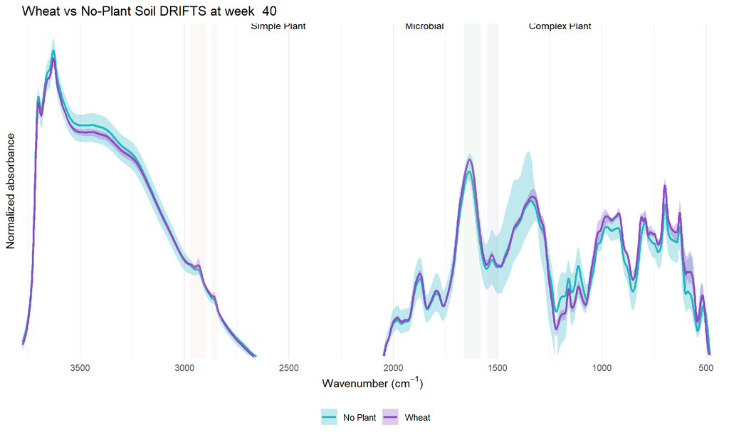

```r
# Create generic function to plot a single crop vs noPlant at a specific timepoint
plot_crop_vs_noplant <- function(data, crop_name, timepoint_week) {
  # Filter data for specific crop and timepoint
  filtered_data <- data %>%
    filter(crop %in% c("noPlant", crop_name), timepoint == timepoint_week) %>%
    mutate(snv_plusOne = as.numeric(snv_plusOne))

  # Average + range ribbon for each crop
  summary_data <- filtered_data %>%
    group_by(crop, wavenumber) %>%
    summarise(
      mean_absorbance = mean(snv_plusOne, na.rm = TRUE),
      min_absorbance = min(snv_plusOne, na.rm = TRUE),
      max_absorbance = max(snv_plusOne, na.rm = TRUE),
      .groups = "drop"
    )

  max_y <- max(summary_data$max_absorbance, na.rm = TRUE) + 0.15

  plot <- ggplot(summary_data, aes(x = wavenumber, color = crop, fill = crop)) +
    geom_ribbon(aes(ymin = min_absorbance, ymax = max_absorbance), alpha = 0.3, color = NA) +
    geom_line(aes(y = mean_absorbance), linewidth = 1) +
    scale_x_reverse(limits = c(3777, 422), breaks = seq(500, 3500, by = 500), expand = c(0.001, 0.001)) +
    scale_y_continuous(limits = c(0, max_y), expand = c(0.002, 0.015)) +
    scale_color_manual(values = crop_colors, labels = crop_labels) +
    scale_fill_manual(values = crop_colors, labels = crop_labels) +
    ggtitle(paste(str_to_title(crop_name), "vs No-Plant Soil DRIFTS at week ", str_extract(timepoint_week, "\\d+"))) +
    labs(x = expression("Wavenumber (cm"^-1*")"), y = "Normalized absorbance",
         color = "", fill = "") +
    theme(legend.position = "bottom",
          axis.text.y = element_blank(),
          panel.grid.major.y = element_blank(),
          panel.grid.minor.y = element_blank()
          ) +
    annotate("rect", xmin = 2976, xmax = 2898, ymin = -Inf, ymax = Inf, alpha = 0.12, fill = "#e3c8b1") +
    annotate("rect", xmin = 2870, xmax = 2839, ymin = -Inf, ymax = Inf, alpha = 0.12, fill = "#e3c8b1") +
    annotate("text", x = 2550, y = max_y, label = "Simple Plant", size = 3.3, hjust = 0.5, color = annotation_text_color) +
    annotate("rect", xmin = 1660, xmax = 1580, ymin = -Inf, ymax = Inf, alpha = 0.12, fill = "#a8cbad") +
    annotate("text", x = 1850, y = max_y, label = "Microbial", size = 3.3, hjust = 0.5, color = annotation_text_color) +
    annotate("rect", xmin = 1550, xmax = 1500, ymin = -Inf, ymax = Inf, alpha = 0.12, fill = "#beb5d5") +
    annotate("text", x = 1200, y = max_y, label = "Complex Plant", size = 3.3, hjust = 0.5, color = annotation_text_color)

  return(plot)
}

wheat_vs_noplant_wk40_plot <- plot_crop_vs_noplant(dpt_data_rhizo, "wheat", "wk40")
rice_vs_noplant_wk40_plot <- plot_crop_vs_noplant(dpt_data_rhizo, "rice", "wk40")
soy_vs_noplant_wk40_plot <- plot_crop_vs_noplant(dpt_data_rhizo, "soy", "wk40")

print(wheat_vs_noplant_wk40_plot)
```

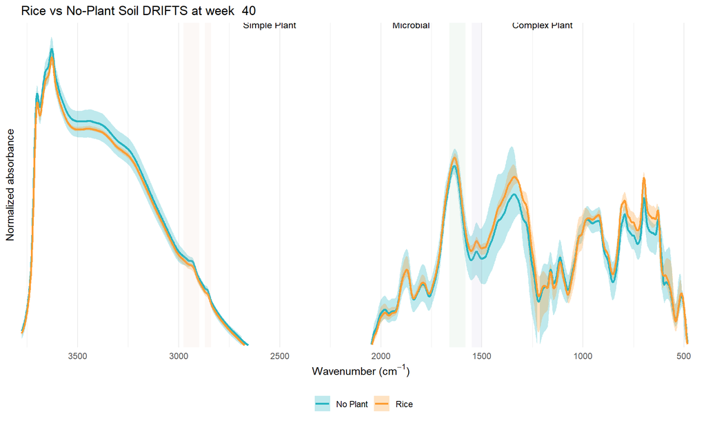

```r
print(rice_vs_noplant_wk40_plot)
```

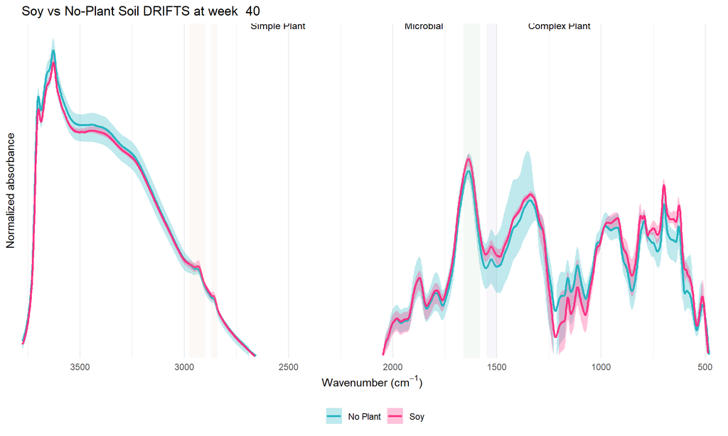

```r
print(soy_vs_noplant_wk40_plot)
```

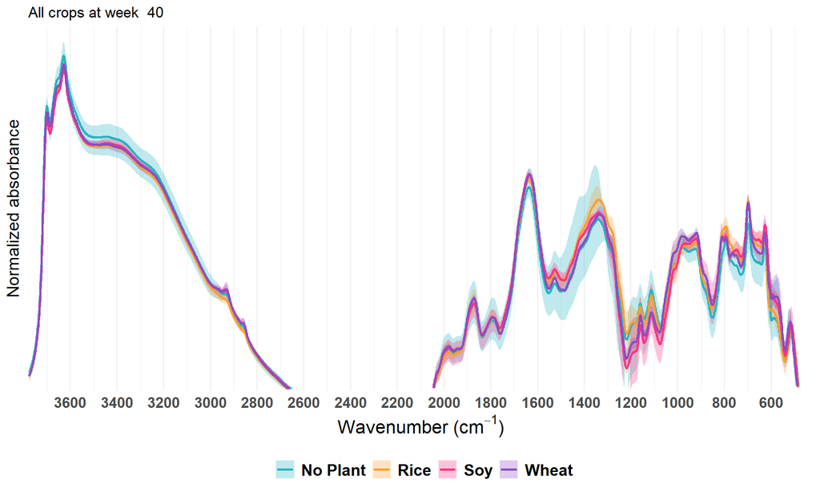

```r
# Create generic function to plot a single crop vs noPlant at a specific timepoint
plot_crops_by_week <- function(data, timepoint_week) {
  # Filter data for specific crop and timepoint
  filtered_data <- data %>%
    filter(timepoint == timepoint_week) %>%
    mutate(snv_plusOne = as.numeric(snv_plusOne))

  # Average + range ribbon for each crop
  summary_data <- filtered_data %>%
    group_by(crop, wavenumber) %>%
    summarise(
      mean_absorbance = mean(snv_plusOne, na.rm = TRUE),
      min_absorbance = min(snv_plusOne, na.rm = TRUE),
      max_absorbance = max(snv_plusOne, na.rm = TRUE),
      .groups = "drop"
    )

  max_y <- max(summary_data$max_absorbance, na.rm = TRUE) + 0.15

  plot <- ggplot(summary_data, aes(x = wavenumber, color = crop, fill = crop)) +
    geom_ribbon(aes(ymin = min_absorbance, ymax = max_absorbance), alpha = 0.3, color = NA) +
    geom_line(aes(y = mean_absorbance), linewidth = 1) +
    scale_x_reverse(limits = c(3777, 422), breaks = seq(400, 3800, by = 200), expand = c(0.001, 0.001)) +
    scale_y_continuous(limits = c(0, max_y), expand = c(0.002, 0.015)) +
    scale_color_manual(values = crop_colors, labels = crop_labels) +
    scale_fill_manual(values = crop_colors, labels = crop_labels) +
    ggtitle(paste("All crops at week ", str_extract(timepoint_week, "\\d+"))) +
    labs(x = expression("Wavenumber (cm"^-1*")"), y = "Normalized absorbance",
         color = "", fill = "") +
    theme(legend.position = "bottom",
      axis.text.y = element_blank(),
      axis.title.y = element_text(size = 14.5),
      axis.text.x = element_text(size = 13, face = "bold"),
      axis.title.x = element_text(size = 16, face = "bold"),
      panel.grid.major.y = element_blank(), # remove horizontal grid lines
      panel.grid.minor.y = element_blank(),  # remove minor horizontal grid lines
      legend.text = element_text(size = 14, face = "bold")
      )

  return(plot)
}

wk40_all_crops_plot <- plot_crops_by_week(dpt_data_rhizo, "wk40")
print(wk40_all_crops_plot)
```

```r
ggsave_themed("all_crops_overlay_wk40.png", wk40_all_crops_plot, width = 10, height = 6)
```

# Combined stacked overlay plot

These chunks create a single visualization showing all crops and timepoints by stacking the overlay plots vertically with a shared y-axis. Each crop has its own color palette and legend. The plots show the average spectra for each crop-timepoint combination with an opaque line (alpha = 1, width = 0.88) and a shaded ribbon representing the range of the data for each crop-timepoint (alpha = 0.58).

This logic is shared by both the 3-crop (no noPlant) and 4-crop (with noPlant) versions below via a common helper function.

### Create helper function

```r
# Builds an "average + range" stacked overlay plot for an arbitrary set of crops.
# data: dpt_data_rhizo (or similar), filtered internally to crops_ordered
# crops_ordered: character vector of crop names, bottom to top in the final plot
# color_map: named list of crop -> named vector of timepoint colors (e.g. color_map_three_sep)
build_stacked_range_plot <- function(data, crops_ordered, color_map, offset_amount = 1.67) {

  plot_data <- data %>%
    filter(crop %in% crops_ordered) %>%
    mutate(crop = factor(crop, levels = crops_ordered)) %>%
    mutate(snv_plusOne = as.numeric(snv_plusOne))

  # Calculate vertical offset for each crop to create stacking effect
  crop_offsets <- setNames(seq(0, length(crops_ordered) - 1) * offset_amount, crops_ordered)

  # Add offset to absorbance values based on crop
  plot_data <- plot_data %>%
    mutate(offset_absorbance = snv_plusOne + crop_offsets[as.character(crop)])

  # Determine max y position for annotations
  max_y <- max(plot_data$offset_absorbance, na.rm = TRUE)

  # Create the base plot with functional region annotations
  base_plot <- ggplot() +
    xlim(3777, 422) +
    ylim(0, max_y) +
    labs(x = expression("Wavenumber (cm"^-1*")"),
         y = "Normalized absorbance") +
    theme(
      axis.text.y = element_blank(),
      axis.title.y = element_text(size = 14.5, face = "bold"),
      axis.text.x = element_text(size = 15, face = "bold"),
      axis.title.x = element_text(size = 16, face = "bold"),
      legend.position = "right",
      legend.justification = c(0, 0.01),  # (x, y) position; 0,0 is bottom-right
      legend.box = "vertical",
      legend.spacing.y = unit(1.8, "cm"),
      legend.title = element_text(size = 15, face = "bold"),
      legend.text = element_text(size = 14.5),
      plot.margin = margin(7, 14, 7, 7, "pt"),  # (top, right, bottom, left)
      panel.grid.major.y = element_blank(),
      panel.grid.minor.y = element_blank()
    ) +
    scale_y_continuous(
      breaks = crop_offsets + 0.003, # y-tick positions
      labels = NULL,
      expand = expansion(mult = c(0.003, 0.015)) # (bottom padding, top padding)
    ) +
    scale_x_reverse(
      limits = c(3770, 415),
      breaks = seq(3500, 500, -500),  # Ticks every 500 from 3500 down to 500
      expand = c(0.002, 0.003)  # Remove padding on x-axis
    ) +
    # Add vertical lines for functional regions
    geom_vline(xintercept = 1500, linetype = "dotted", linewidth = 0.46, color = annotation_text_color, alpha = 0.8) +
    geom_vline(xintercept = 1550, linetype = "dotted", linewidth = 0.46, color = annotation_text_color, alpha = 0.8) +
    geom_vline(xintercept = 1580, linetype = "dashed", linewidth = 0.23, color = annotation_text_color, alpha = 0.8) +
    geom_vline(xintercept = 1660, linetype = "dashed", linewidth = 0.23, color = annotation_text_color, alpha = 0.8) +
    geom_vline(xintercept = 2839, linetype = "longdash", linewidth = 0.23, color = annotation_text_color, alpha = 0.8) +
    geom_vline(xintercept = 2870, linetype = "longdash", linewidth = 0.23, color = annotation_text_color, alpha = 0.8) +
    geom_vline(xintercept = 2898, linetype = "longdash", linewidth = 0.23, color = annotation_text_color, alpha = 0.8) +
    geom_vline(xintercept = 2976, linetype = "longdash", linewidth = 0.23, color = annotation_text_color, alpha = 0.8) +
    # Add shaded regions with annotations
    annotate("rect", xmin = 2976, xmax = 2898, ymin = -Inf, ymax = Inf,
             alpha = 0.3, fill = "#e3c8b1") +
    annotate("rect", xmin = 2870, xmax = 2839, ymin = -Inf, ymax = Inf,
             alpha = 0.3, fill = "#e3c8b1") +
    annotate("text", x = 2650, y = max_y - 0.05, label = "Simple Plant",
             size = 4.9, fontface = "bold", hjust = 0.5, color = annotation_text_color) +
    annotate("rect", xmin = 1660, xmax = 1580, ymin = -Inf, ymax = Inf,
             alpha = 0.3, fill = "#a8cbad") +
    annotate("text", x = 1800, y = max_y, label = "Microbial",
             size = 4.9, fontface = "bold", hjust = 0.5, color = annotation_text_color) +
    annotate("rect", xmin = 1550, xmax = 1500, ymin = -Inf, ymax = Inf,
             alpha = 0.3, fill = "#beb5d5") +
    annotate("text", x = 1300, y = max_y, label = "Complex Plant",
             size = 4.9, fontface = "bold", hjust = 0.5, color = annotation_text_color)

  # Add layers for each crop with average and range
  combined_plot <- base_plot

  for (crop in crops_ordered) {
    crop_data <- plot_data %>% filter(crop == !!crop)

    for (tp in names(color_map[[crop]])) {
      tp_data <- crop_data %>% filter(timepoint == tp)
      if (nrow(tp_data) == 0) next

      # Calculate average and range for this crop+timepoint combination
      summary_data <- tp_data %>%
        group_by(wavenumber) %>%
        summarise(
          mean_absorbance = mean(offset_absorbance, na.rm = TRUE),
          min_absorbance = min(offset_absorbance, na.rm = TRUE),
          max_absorbance = max(offset_absorbance, na.rm = TRUE),
          .groups = "drop"
        )

      # Add range ribbon (semi-transparent)
      combined_plot <- combined_plot +
        geom_ribbon(data = summary_data,
                    aes(x = wavenumber, ymin = min_absorbance, ymax = max_absorbance),
                    fill = color_map[[crop]][tp],
                    alpha = 0.58,
                    color = NA,
                    show.legend = FALSE)

      # Add average line (opaque)
      combined_plot <- combined_plot +
        geom_line(data = summary_data,
                  aes(x = wavenumber, y = mean_absorbance),
                  color = color_map[[crop]][tp],
                  linewidth = 0.88,
                  alpha = 1,
                  show.legend = FALSE)
    }
  }

  # Build one legend per crop using invisible dummy layers + ggnewscale, so each
  # crop keeps its own color palette in its own legend block.
  # crops_ordered goes bottom-to-top in the actual plot (first element = bottom offset),
  # so the legend blocks are built in the REVERSE order to match: the crop at the top of
  # the plot gets the top legend block, working down to the crop at the bottom.
  if (!require(ggnewscale, quietly = TRUE)) {
    install.packages("ggnewscale")
    library(ggnewscale)
  }

  legend_order_crops <- rev(crops_ordered)

  for (i in seq_along(legend_order_crops)) {
    crop <- legend_order_crops[i]

    # Only include timepoints that actually have data for this crop - color_map may
    # define a color for every possible timepoint even if some weren't collected
    present_tps <- names(color_map[[crop]])[
      names(color_map[[crop]]) %in% unique(as.character(plot_data$timepoint[plot_data$crop == crop]))
    ]
    if (length(present_tps) == 0) next

    dummy_data <- data.frame(
      x = rep(3777, length(present_tps)),
      y = rep(0, length(present_tps)),
      tp = present_tps
    )

    combined_plot <- combined_plot +
      geom_line(data = dummy_data, aes(x = x, y = y, color = tp), linewidth = 0, alpha = 0) +
      scale_color_manual(
        name = str_to_title(crop),
        values = color_map[[crop]][present_tps],
        breaks = present_tps,
        labels = present_tps,
        guide = guide_legend(override.aes = list(linewidth = 3, alpha = 1), order = i)
      )

    if (i < length(legend_order_crops)) {
      combined_plot <- combined_plot + ggnewscale::new_scale_color()
    }
  }

  return(list(plot = combined_plot, data = plot_data))
}
```

### Plot without no-plant control (3 crops only)

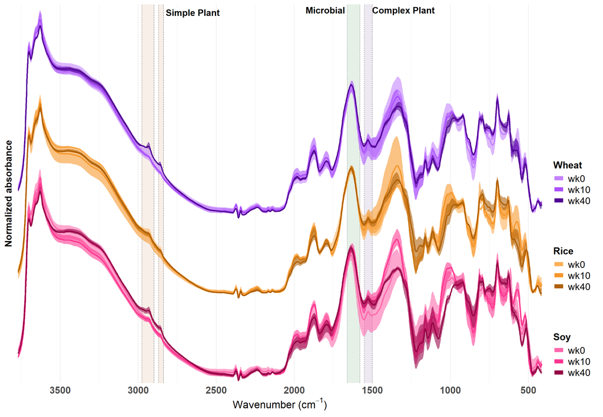

```r
crop_timepoint_colors_three <- color_map_three_sep
crops_ordered_three <- c("soy", "rice", "wheat")  # Reversed for plotting so soy appears at top

three_crop_result <- build_stacked_range_plot(
  data = dpt_data_rhizo,
  crops_ordered = crops_ordered_three,
  color_map = crop_timepoint_colors_three
)

print(three_crop_result$plot)
```

```r
ggsave_themed("combined_overlay_range_no_noplant.png", three_crop_result$plot, width = 13, height = 9, dpi = 300)

count_table_three <- count_samples_by_group(three_crop_result$data)
knitr::kable(
  count_table_three,
  format = "html",
  escape = FALSE,
  col.names = c("Crop", "Timepoint", "Sample Type", "N samples")
) |>
  kableExtra::kable_styling(
    full_width = FALSE,
    position = "left"
  )
```

| Crop | Timepoint | Sample Type | N samples |
| --- | --- | --- | --- |
| wheat | wk0 | rhizoSoil | 5 |
| wheat | wk10 | rhizoSoil | 3 |
| wheat | wk40 | rhizoSoil | 3 |
| rice | wk0 | rhizoSoil | 3 |
| rice | wk10 | rhizoSoil | 5 |
| rice | wk40 | rhizoSoil | 3 |
| soy | wk0 | rhizoSoil | 3 |
| soy | wk10 | rhizoSoil | 3 |
| soy | wk40 | rhizoSoil | 3 |

### Including all four crops (with no-plant control)

Same as above, but including noPlant alongside wheat, rice, and soy.

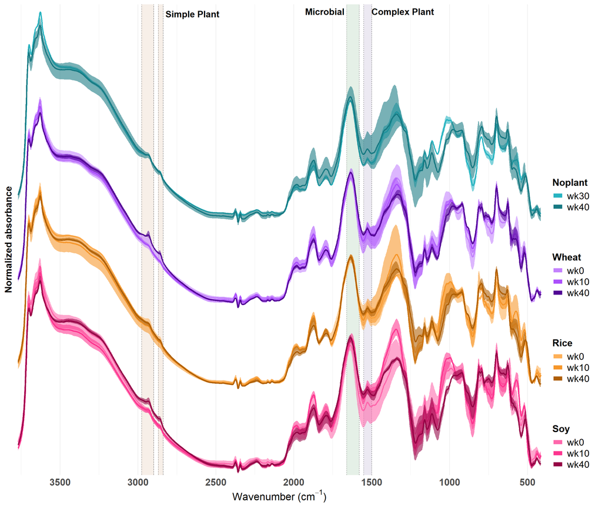

```r
crop_timepoint_colors_four <- color_map_all_sep
crops_ordered_four <- c("soy", "rice", "wheat", "noPlant")  # Reversed for plotting so soy appears at top

four_crop_result <- build_stacked_range_plot(
  data = dpt_data_rhizo,
  crops_ordered = crops_ordered_four,
  color_map = crop_timepoint_colors_four
)

print(four_crop_result$plot)
```

```r
ggsave_themed("combined_overlay_range_all_crops.png", four_crop_result$plot, width = 13, height = 11, dpi = 300)

count_table_four <- count_samples_by_group(four_crop_result$data)

knitr::kable(
  count_table_four,
  format = "html",
  escape = FALSE,
  col.names = c("Crop", "Timepoint", "Sample Type", "N samples")
) |>
  kableExtra::kable_styling(
    full_width = FALSE,
    position = "left"
  )
```

| Crop | Timepoint | Sample Type | N samples |
| --- | --- | --- | --- |
| noPlant | wk30 | rhizoSoil | 2 |
| noPlant | wk40 | rhizoSoil | 6 |
| wheat | wk0 | rhizoSoil | 5 |
| wheat | wk10 | rhizoSoil | 3 |
| wheat | wk40 | rhizoSoil | 3 |
| rice | wk0 | rhizoSoil | 3 |
| rice | wk10 | rhizoSoil | 5 |
| rice | wk40 | rhizoSoil | 3 |
| soy | wk0 | rhizoSoil | 3 |
| soy | wk10 | rhizoSoil | 3 |
| soy | wk40 | rhizoSoil | 3 |

# Comparing regions of interest

## Integrating spectral regions

This code chunk performs the integration of the spectral regions of interest for each sample and calculates the derived metrics (simple plant, complex plant, microbial proportions, etc.) based on the integrated areas. The results are combined with the existing metadata from the DPT data and saved as a csv file (“processed_int_data_[date].csv”).

```r
# Function to perform spectral integration on DPT data (based on Leila_code_modified.Rmd)
perform_spectral_integration <- function(dpt_data) {
  cat("Starting spectral integration processing...\n")

  # Load required library for integration
  if (!require(pracma, quietly = TRUE)) {
    install.packages("pracma")
    library(pracma)
  }

  # Prepare the data in the format needed for integration
  # Rename columns to match expected format
  comb <- dpt_data %>%
    select(filename, wavenumber, snv_corrected) %>%
    rename(sample = filename, wavelength = wavenumber, abs = snv_corrected)

  # Define spectral windows of interest (same as Leila's code)
  red1 <- comb[comb$wavelength > 2839 & comb$wavelength < 2870, ]  # Aliphatic 1
  red2 <- comb[comb$wavelength > 2898 & comb$wavelength < 2976, ]  # Aliphatic 2
  red3 <- comb[comb$wavelength > 1580 & comb$wavelength < 1660, ]  # Microbial
  red4 <- comb[comb$wavelength > 1500 & comb$wavelength < 1550, ]  # Complex plant

  # Get unique samples
  sample <- unique(comb$sample)

  # Create integration results data frame
  ints <- data.frame(
    sample = sample,
    int_2839_2870 = numeric(length(sample)),
    int_2898_2976 = numeric(length(sample)),
    int_1580_1660 = numeric(length(sample)),
    int_1500_1550 = numeric(length(sample)),
    stringsAsFactors = FALSE
  )

  # Calculate integrated areas for each spectral window and sample
  cat("Processing", length(sample), "samples for integration...\n")
  for (i in seq_len(nrow(ints))) {
    current_sample <- sample[i]

    # Extract data for current sample from each spectral window
    sample_red1 <- red1[red1$sample == current_sample, ]
    sample_red2 <- red2[red2$sample == current_sample, ]
    sample_red3 <- red3[red3$sample == current_sample, ]
    sample_red4 <- red4[red4$sample == current_sample, ]

    # Calculate area under curve (integration) using trapezoidal rule
    if (nrow(sample_red1) > 1) {
      ints$int_2839_2870[i] <- pracma::trapz(sample_red1$wavelength, sample_red1$abs)
    }

    if (nrow(sample_red2) > 1) {
      ints$int_2898_2976[i] <- pracma::trapz(sample_red2$wavelength, sample_red2$abs)
    }

    if (nrow(sample_red3) > 1) {
      ints$int_1580_1660[i] <- pracma::trapz(sample_red3$wavelength, sample_red3$abs)
    }

    if (nrow(sample_red4) > 1) {
      ints$int_1500_1550[i] <- pracma::trapz(sample_red4$wavelength, sample_red4$abs)
    }
  }

  # Use existing metadata from the input data (no need to re-extract)
  cat("Using existing metadata from DPT data...\n")
  basic_meta <- dpt_data %>%
    select(filename, crop, timepoint, sample_type, ID) %>%
    distinct() %>%
    rename(sample = filename, type = sample_type)

  # Combine metadata with integration results
  ftir_data <- merge(basic_meta, ints, by = "sample", all = TRUE)

  # Rename integration columns to match expected names
  names(ftir_data)[names(ftir_data) == "int_1580_1660"] <- "int_microbial"
  names(ftir_data)[names(ftir_data) == "int_1500_1550"] <- "int_complex_plant"

  # Calculate derived metrics (same as original)
  ftir_data$aliphatic <- ftir_data$int_2839_2870 + ftir_data$int_2898_2976
  ftir_data$total_peak_area <- ftir_data$aliphatic + ftir_data$int_microbial + ftir_data$int_complex_plant
  ftir_data$simple_plant_prop <- ftir_data$aliphatic / ftir_data$total_peak_area
  ftir_data$complex_plant_prop <- ftir_data$int_complex_plant / ftir_data$total_peak_area
  ftir_data$microbial_prop <- ftir_data$int_microbial / ftir_data$total_peak_area
  ftir_data$simple_microbial_prop <- ftir_data$simple_plant_prop / ftir_data$microbial_prop
  ftir_data$complex_microbial_prop <- ftir_data$complex_plant_prop / ftir_data$microbial_prop

  # Remove individual aliphatic integration columns (keep only derived metrics)
  ftir_data <- ftir_data %>%
    select(-int_2839_2870, -int_2898_2976)

  # Save the processed data to the output directory
  today <- format(Sys.Date(), "%Y-%m-%d")
  output_file <- file.path(outputs_folder, paste0("processed_int_data_", today, ".csv"))
  write.csv(ftir_data, file = output_file, row.names = FALSE)
  cat("Saved processed integration data to:", output_file, "\n")

  cat("Integration processing completed successfully.\n")
  return(ftir_data)
}
```

## Generating statistics

This code chunk calculates summary statistics (mean and standard error) for the derived metrics (simple plant, complex plant, microbial proportions) grouped by crop, timepoint, and crop-timepoint combinations. The results are stored in separate data frames for later visualization.

```r
# Try to find the most recent processed integration data file
ftir_file <- find_most_recent_processed_file(outputs_folder)

if (!is.null(ftir_file) && file.exists(ftir_file)) {
  ftir_data <- read_csv(ftir_file, show_col_types = FALSE)
  cat("Successfully loaded FTIR integration data from:", basename(ftir_file), "\n")
  cat("Dimensions:", dim(ftir_data), "\n")
  cat("Columns:", names(ftir_data), "\n")
} else {
  cat("No processed integration data found. Processing raw DPT data to generate integration results...\n")

  # Check if we have the required dpt_data_rhizo from previous chunk
  if (!exists("dpt_data_rhizo") || nrow(dpt_data_rhizo) == 0) {
    stop("No DPT data available for integration. Please ensure the DPT data import was successful.")
  }

  # Process raw DPT data using the integrated function
  ftir_data <- perform_spectral_integration(dpt_data_rhizo)

  # Verify the processing was successful
  if (is.null(ftir_data) || nrow(ftir_data) == 0) {
    stop("Failed to process DPT data for integration.")
  }

  cat("Successfully processed", nrow(ftir_data), "samples from DPT data\n")
  cat("Generated columns:", names(ftir_data), "\n")
}
```

```
## No processed integration data found. Processing raw DPT data to generate integration results...
## Starting spectral integration processing...
## Processing 39 samples for integration...
## Using existing metadata from DPT data...
## Saved processed integration data to: C:/Users/adria/Box/Salk Institute Project/AKS Salk files/Camryn_DRIFTSdata/code_outputs/processed_int_data_2026-08-05.csv
## Integration processing completed successfully.
## Successfully processed 39 samples from DPT data
## Generated columns: sample crop timepoint type ID int_microbial int_complex_plant aliphatic total_peak_area simple_plant_prop complex_plant_prop microbial_prop simple_microbial_prop complex_microbial_prop
```

```r
# Calculate summary statistics by group
crop_stats <- ftir_data %>%
  mutate(crop = factor(crop, levels = c("noPlant", "wheat", "rice", "soy"))) %>%
  group_by(crop) %>%
  summarise(
    Mean_simple_plant_prop = mean(simple_plant_prop, na.rm = TRUE),
    SE_simple_plant_prop = sd(simple_plant_prop, na.rm = TRUE) / sqrt(n()),
    Mean_complex_plant_prop = mean(complex_plant_prop, na.rm = TRUE),
    SE_complex_plant_prop = sd(complex_plant_prop, na.rm = TRUE) / sqrt(n()),
    Mean_microbial_prop = mean(microbial_prop, na.rm = TRUE),
    SE_microbial_prop = sd(microbial_prop, na.rm = TRUE) / sqrt(n()),
    .groups = 'drop'
  )

timepoint_stats <- ftir_data %>%
  group_by(timepoint) %>%
  summarise(
    Mean_simple_plant_prop = mean(simple_plant_prop, na.rm = TRUE),
    SE_simple_plant_prop = sd(simple_plant_prop, na.rm = TRUE) / sqrt(n()),
    Mean_complex_plant_prop = mean(complex_plant_prop, na.rm = TRUE),
    SE_complex_plant_prop = sd(complex_plant_prop, na.rm = TRUE) / sqrt(n()),
    Mean_microbial_prop = mean(microbial_prop, na.rm = TRUE),
    SE_microbial_prop = sd(microbial_prop, na.rm = TRUE) / sqrt(n()),
    .groups = 'drop'
  )

crop_timepoint_stats <- ftir_data %>%
  mutate(crop = factor(crop, levels = c("noPlant", "wheat", "rice", "soy"))) %>%
  group_by(crop, timepoint) %>%
  summarise(
    Mean_simple_plant_prop = mean(simple_plant_prop, na.rm = TRUE),
    SE_simple_plant_prop = sd(simple_plant_prop, na.rm = TRUE) / sqrt(n()),
    Mean_complex_plant_prop = mean(complex_plant_prop, na.rm = TRUE),
    SE_complex_plant_prop = sd(complex_plant_prop, na.rm = TRUE) / sqrt(n()),
    Mean_microbial_prop = mean(microbial_prop, na.rm = TRUE),
    SE_microbial_prop = sd(microbial_prop, na.rm = TRUE) / sqrt(n()),
    .groups = 'drop'
  )
```

# Visualizing integrated ranges

The following code chunks are modified from “Berhe_Ghezzehei_Lab/DRIFTS Data Analysis/Visualizing_FTIR_w_Elemental_Data.R”. They create bar plots showing the mean and standard error of the simple plant, complex plant, and microbial proportions for each crop and timepoint, based on the summary statistics calculated earlier.

## Proportion plots by crop

These plots show the mean and standard error of the simple plant, complex plant, and microbial proportions grouped by crop, pooling together all timepoints. It also defines the generic function `create_proportion_plots` which is used the next code chunk.

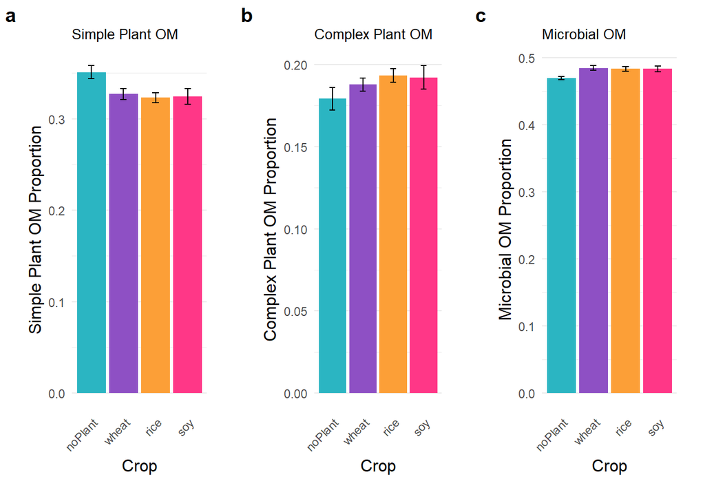

```r
# Recreate the plotting function from Leila's code
create_proportion_plots <- function(stats_data, group_col, title_prefix) {
  # Choose colors based on grouping variable
  colors_to_use <- if(group_col == "crop") crop_colors else timepoint_colors

  p1 <- ggplot(data = stats_data, aes_string(x = group_col, y = "Mean_simple_plant_prop", fill = group_col)) +
    geom_col(alpha = 0.98) +
    geom_errorbar(aes_string(ymin = "Mean_simple_plant_prop - SE_simple_plant_prop",
                            ymax = "Mean_simple_plant_prop + SE_simple_plant_prop"),
                  width = 0.2,
                  color = annotation_text_color) +

    scale_fill_manual(values = colors_to_use) +
    labs(title = paste0(title_prefix, "Simple Plant OM"),
         x = str_to_title(group_col),
         y = "Simple Plant OM Proportion") +
    theme(legend.position = "none",
          axis.text.x = element_text(angle = 45, hjust = 1),
          plot.margin = margin(20, 20, 20, 20),
          axis.title = element_text(size = 12),
          plot.title = element_text(size = 10),
          panel.grid.major.x = element_blank(),
          panel.grid.minor.x = element_blank())

  p2 <- ggplot(data = stats_data, aes_string(x = group_col, y = "Mean_complex_plant_prop", fill = group_col)) +
    geom_col(alpha = 0.98) +
    geom_errorbar(aes_string(ymin = "Mean_complex_plant_prop - SE_complex_plant_prop",
                            ymax = "Mean_complex_plant_prop + SE_complex_plant_prop"),
                  width = 0.2,
                  color = annotation_text_color) +

    scale_fill_manual(values = colors_to_use) +
    labs(title = paste0(title_prefix, "Complex Plant OM"),
         x = str_to_title(group_col),
         y = "Complex Plant OM Proportion") +
    theme(legend.position = "none",
          axis.text.x = element_text(angle = 45, hjust = 1),
          plot.margin = margin(20, 20, 20, 20),
          axis.title = element_text(size = 12),
          plot.title = element_text(size = 10),
          panel.grid.major.x = element_blank(),
          panel.grid.minor.x = element_blank())

  p3 <- ggplot(data = stats_data, aes_string(x = group_col, y = "Mean_microbial_prop", fill = group_col)) +
    geom_col(alpha = 0.98) +
    geom_errorbar(aes_string(ymin = "Mean_microbial_prop - SE_microbial_prop",
                            ymax = "Mean_microbial_prop + SE_microbial_prop"),
                  width = 0.2,
                  color = annotation_text_color) +

    scale_fill_manual(values = colors_to_use) +
    labs(title = paste0(title_prefix, "Microbial OM"),
         x = str_to_title(group_col),
         y = "Microbial OM Proportion") +
    theme(legend.position = "none",
          axis.text.x = element_text(angle = 45, hjust = 1),
          plot.margin = margin(20, 20, 20, 20),
          axis.title = element_text(size = 12),
          plot.title = element_text(size = 10),
          panel.grid.major.x = element_blank(),
          panel.grid.minor.x = element_blank())

  list(p1 = p1, p2 = p2, p3 = p3)
}

# Create EXACT plots by crop (from Leila_code_modified.Rmd)
crop_plots <- create_proportion_plots(crop_stats, "crop", "")
crop_combined <- plot_grid(crop_plots$p1, crop_plots$p2, crop_plots$p3, nrow = 1, labels = "auto")
print(crop_combined)
```

## Proportion plots by timepoint

These plots show the mean and standard error of the simple plant, complex plant, and microbial proportions at each timepoint, pooling together wheat, soy and rice samples. No-plant samples are excluded from this figure. Uses the same `create_proportion_plots` function defined in the previous chunk.

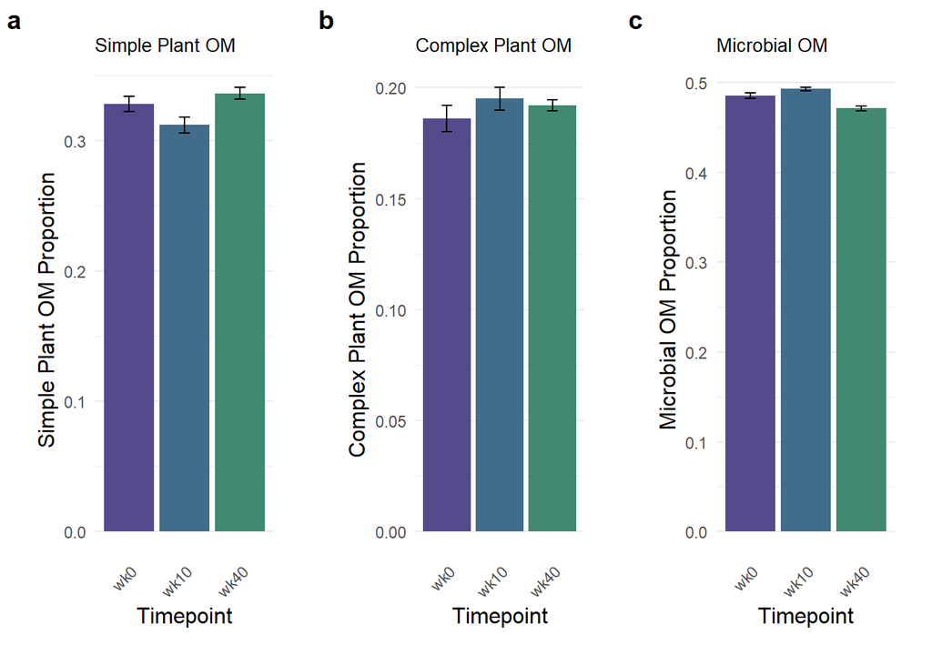

```r
# Create plots by timepoint from Leila's code

timepoint_stats_no_noplant <- ftir_data %>%
  filter(crop != "noPlant") %>%
  group_by(timepoint) %>%
  summarise(
    Mean_simple_plant_prop = mean(simple_plant_prop, na.rm = TRUE),
    SE_simple_plant_prop = sd(simple_plant_prop, na.rm = TRUE) / sqrt(n()),
    Mean_complex_plant_prop = mean(complex_plant_prop, na.rm = TRUE),
    SE_complex_plant_prop = sd(complex_plant_prop, na.rm = TRUE) / sqrt(n()),
    Mean_microbial_prop = mean(microbial_prop, na.rm = TRUE),
    SE_microbial_prop = sd(microbial_prop, na.rm = TRUE) / sqrt(n()),
    .groups = 'drop'
  )

timepoint_plots <- create_proportion_plots(timepoint_stats_no_noplant, "timepoint", "")
timepoint_combined <- plot_grid(timepoint_plots$p1, timepoint_plots$p2, timepoint_plots$p3, nrow = 1, labels = "auto")
print(timepoint_combined)
```

## Crop x timepoint interaction plots

This chunk creates 3 separate figures for simple plant, complex plant and microbial OM proportions, with plots showing the mean and standard error for each crop at each timepoint, allowing for comparison of the interaction between crop type and timepoint.

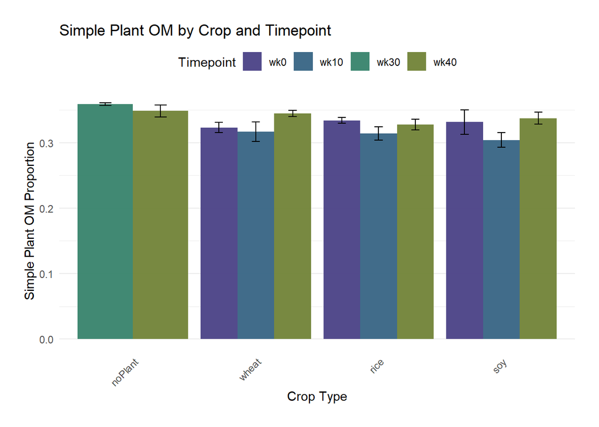

```r
# SIMPLE PLANT PROPORTION INTERACTION PLOT
# Recreate simple plant proportion interaction plot (crop x timepoint) from Leila's code
interaction_plot <- ggplot(crop_timepoint_stats) +
  geom_col(aes(x = crop, y = Mean_simple_plant_prop, fill = timepoint),
           position = "dodge", alpha = 0.98) +
  geom_errorbar(aes(x = crop,
                    ymin = Mean_simple_plant_prop - SE_simple_plant_prop,
                    ymax = Mean_simple_plant_prop + SE_simple_plant_prop,
                    group = timepoint),
                position = position_dodge(0.9), width = 0.2, color = annotation_text_color) +

  scale_fill_manual("Timepoint", values = timepoint_colors) +
  labs(title = "Simple Plant OM by Crop and Timepoint",
       x = "Crop Type",
       y = "Simple Plant OM Proportion") +
  theme(legend.position = "top",
        plot.margin = margin(20, 20, 20, 20),
        axis.text.x = element_text(angle = 45, hjust = 1),
        panel.grid.major.x = element_blank(),
        panel.grid.minor.x = element_blank())

print(interaction_plot)
```

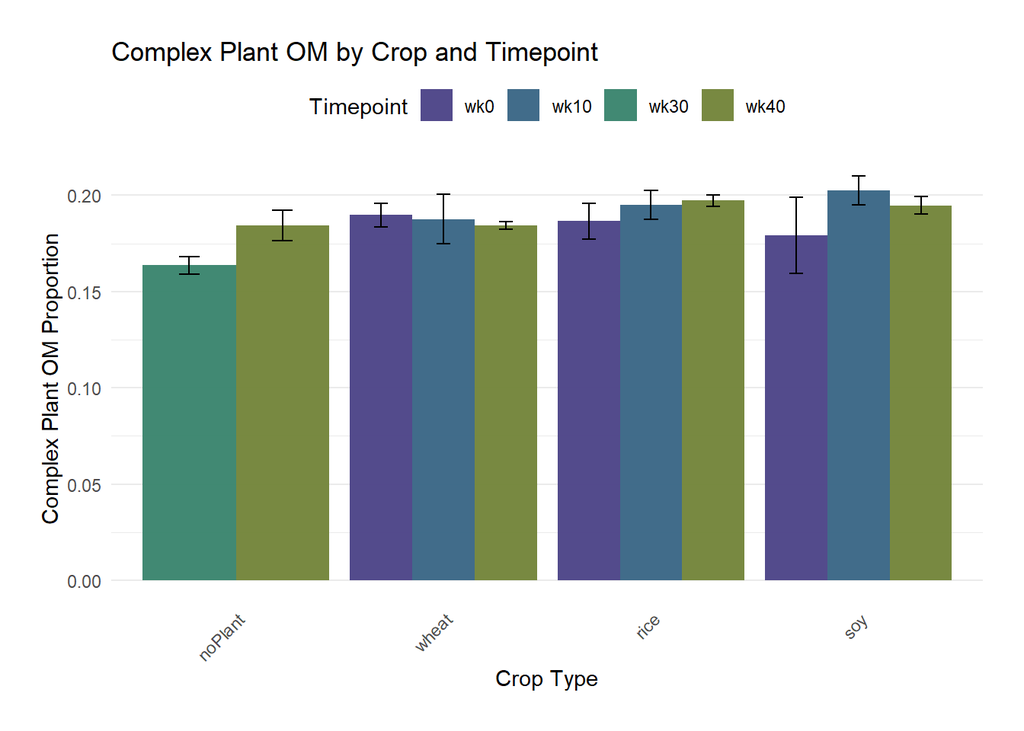

```r
# COMPLEX PLANT PROPORTION INTERACTION PLOT
CP_interaction_plot <- ggplot(crop_timepoint_stats) +
  geom_col(aes(x = crop, y = Mean_complex_plant_prop, fill = timepoint),
           position = "dodge", alpha = 0.98) +
  geom_errorbar(aes(x = crop,
                    ymin = Mean_complex_plant_prop - SE_complex_plant_prop,
                    ymax = Mean_complex_plant_prop + SE_complex_plant_prop,
                    group = timepoint),
                position = position_dodge(0.9), width = 0.2, color = annotation_text_color) +

  scale_fill_manual("Timepoint", values = timepoint_colors) +
  labs(title = "Complex Plant OM by Crop and Timepoint",
       x = "Crop Type",
       y = "Complex Plant OM Proportion") +
  theme(legend.position = "top",
        plot.margin = margin(20, 20, 20, 20),
        axis.text.x = element_text(angle = 45, hjust = 1),
        panel.grid.major.x = element_blank(),
        panel.grid.minor.x = element_blank())

print(CP_interaction_plot)
```

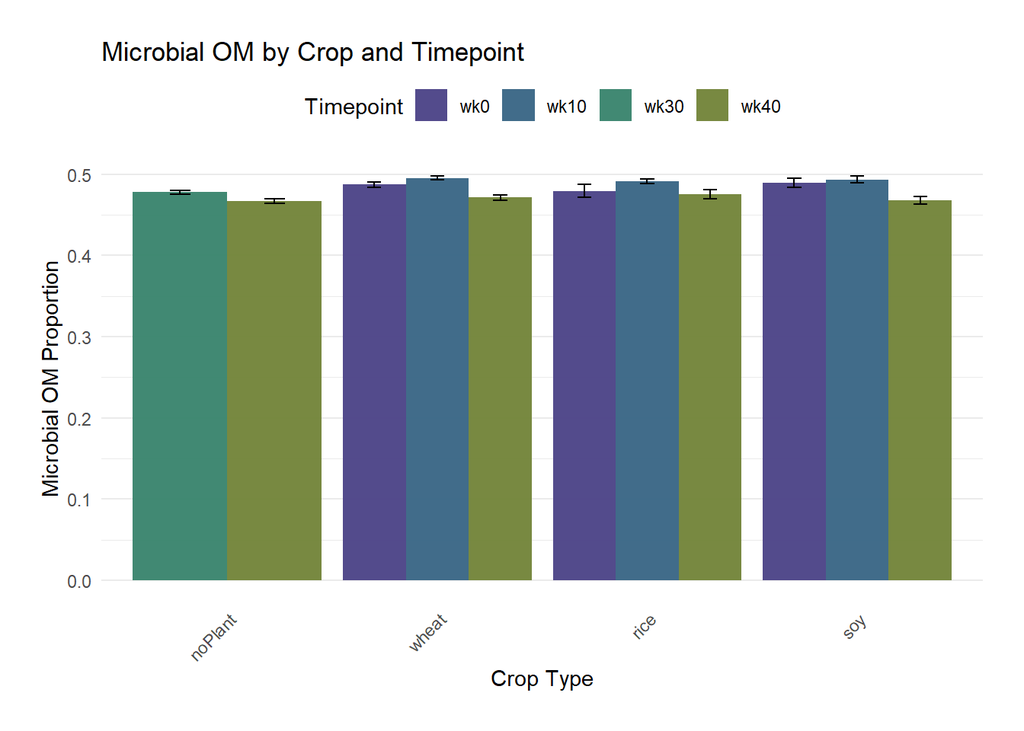

```r
# MICROBIAL PROPORTION INTERACTION PLOT
micr_interaction_plot <- ggplot(crop_timepoint_stats) +
  geom_col(aes(x = crop, y = Mean_microbial_prop, fill = timepoint),
           position = "dodge", alpha = 0.98) +
  geom_errorbar(aes(x = crop,
                    ymin = Mean_microbial_prop - SE_microbial_prop,
                    ymax = Mean_microbial_prop + SE_microbial_prop,
                    group = timepoint),
                position = position_dodge(0.9), width = 0.2, color = annotation_text_color) +

  scale_fill_manual("Timepoint", values = timepoint_colors) +
  labs(title = "Microbial OM by Crop and Timepoint",
       x = "Crop Type",
       y = "Microbial OM Proportion") +
  theme(legend.position = "top",
        plot.margin = margin(20, 20, 20, 20),
        axis.text.x = element_text(angle = 45, hjust = 1),
        panel.grid.major.x = element_blank(),
        panel.grid.minor.x = element_blank())

print(micr_interaction_plot)
```

## Stacked interaction plots (crop x timepoint)

The following code chunk creates a stacked bar plot showing the proportions (with labels in percent) of simple plant, complex plant, and microbial OM for each crop at each timepoint, allowing for visualization of the interactive effect of crop type and timepoint on all three regions in a single figure.

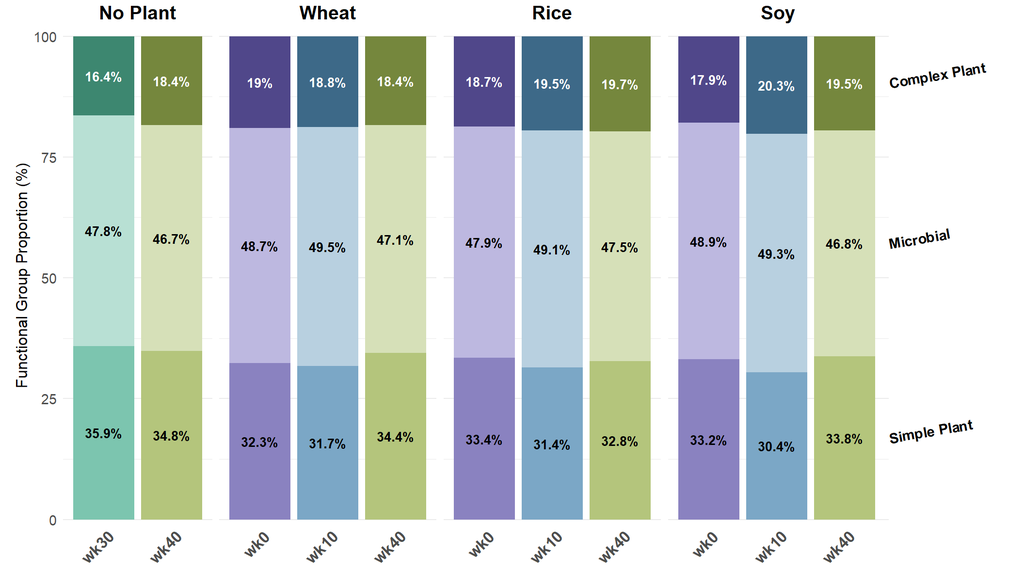

```r
timepoint_prop_colors <- list(
  "wk0" = c("Simple Plant" = "#8a82c0", "Microbial" = "#bdb8e0", "Complex Plant" = "#50478A"),
  "wk10" = c("Simple Plant" = "#7ba7c6", "Microbial" = "#b8d0e0", "Complex Plant" = "#3D6988"),
  "wk20" = c("Simple Plant" = "#c5aa7c", "Microbial" = "#e0d1b8", "Complex Plant" = "#876B3D"),
  "wk30" = c("Simple Plant" = "#7cc5af", "Microbial" = "#b8e0d4", "Complex Plant" = "#3D8770"),
  "wk40" = c("Simple Plant" = "#b4c57c", "Microbial" = "#d6e0b8", "Complex Plant" = "#75873D")
)

# Stacked interaction plot - crop x timepoint with all three proportions
# Create stacked data for interaction plot
interaction_stacked_data <- crop_timepoint_stats %>%
  select(crop, timepoint, Mean_simple_plant_prop, Mean_complex_plant_prop, Mean_microbial_prop) %>%
  pivot_longer(cols = starts_with("Mean_"),
               names_to = "func_type",
               values_to = "proportion") %>%
  mutate(func_type = case_when(
    func_type == "Mean_simple_plant_prop" ~ "Simple Plant",
    func_type == "Mean_microbial_prop" ~ "Microbial",
    func_type == "Mean_complex_plant_prop" ~ "Complex Plant"
  )) %>%
  mutate(func_type = factor(func_type, levels = c("Simple Plant", "Microbial", "Complex Plant")))

# Create a combined group for positioning (crop:timepoint)
interaction_stacked_data <- interaction_stacked_data %>%
  mutate(crop_time = interaction(crop, timepoint, sep = "_"))

# Apply colors - using average of timepoint colors for each functional group
# Or better - use timepoint-specific colors from timepoint_prop_colors
# Create fill based on timepoint:func_type combination
interaction_stacked_data <- interaction_stacked_data %>%
  mutate(fill_group = paste(timepoint, func_type, sep = "_"))

# Create manual color scale using timepoint_prop_colors
color_values <- c()
color_names <- c()
for (tp in c("wk0", "wk10", "wk20", "wk30", "wk40")) {
  for (ft in c("Simple Plant", "Microbial", "Complex Plant")) {
    color_names <- c(color_names, paste(tp, ft, sep = "_"))
    color_values <- c(color_values, timepoint_prop_colors[[tp]][ft])
  }
}
names(color_values) <- color_names
create_stacked_interaction_plot <- function(interaction_stacked_data,
                                            include_noPlant = TRUE) {

  plot_data <- interaction_stacked_data

  if (!include_noPlant) {
    plot_data <- plot_data %>%
      filter(crop != "noPlant")
  }

  interaction_plot <- ggplot(
    plot_data,
    aes(
      x = interaction(crop, timepoint),
      y = proportion * 100,
      fill = fill_group
    )
  ) +
    geom_col(position = "stack") +
    facet_grid(
      . ~ crop,
      scales = "free_x",
      space = "free_x",
      labeller = labeller(crop = crop_labels)
    ) +
    scale_x_discrete(labels = function(x) {
      sapply(strsplit(as.character(x), "\\."), `[`, 2)
    }) +
    scale_y_continuous(expand = expansion(mult = c(0.01, 0.02))) +
    labs(
      x = "",
      y = "Functional Group Proportion (%)",
      fill = ""
    ) +
    theme(
      legend.position = "none",
      plot.margin = margin(-2, 105, 0, 12),
      axis.text.x = element_text(angle = 45, hjust = .9, size = 12.5, face = "bold"),
      axis.title.y = element_text(size = 12),
      axis.text.y = element_text(size = 11),
      strip.background = element_blank(),
      strip.text = element_text(size = 14.5, face = "bold",
                                color = annotation_text_color),
      panel.grid.major.x = element_blank(),
      panel.grid.minor.x = element_blank()
    ) +
    coord_cartesian(clip = "off") +
    scale_fill_manual(
      values = color_values,
      labels = function(x) {
        parts <- strsplit(x, "_")
        sapply(parts, function(p) paste(p[1], p[2], sep = " - "))
      }
    )

  ## ---------- percentage labels ----------

  label_data <- plot_data %>%
    group_by(crop, timepoint) %>%
    arrange(func_type) %>%
    mutate(
      cum_prop = cumsum(proportion * 100),
      label_y = cum_prop - (proportion * 100) / 2,
      pct_label = paste0(round(proportion * 100, 1), "%"),
      label_color = ifelse(func_type == "Complex Plant",
                           "white",
                           "black")
    ) %>%
    ungroup()

  functype_label_data <- label_data %>%
    filter(
      crop == "soy",
      timepoint == "wk40"
    )

  interaction_plot +
    geom_text(
      data = label_data,
      aes(
        x = interaction(crop, timepoint),
        y = label_y,
        label = pct_label,
        color = label_color
      ),
      size = 3.5,
      fontface = "bold",
      inherit.aes = FALSE
    ) +
    scale_color_identity() +
    geom_text(
      data = functype_label_data,
      aes(
        x = interaction(crop, timepoint),
        y = label_y,
        label = func_type
      ),
      hjust = 0,
      nudge_x = if (include_noPlant) 0.65 else 0.5,
      size = 3.8,
      angle = 10,
      fontface = "bold",
      color = annotation_text_color,
      inherit.aes = FALSE
    )
}

interaction_plot_stacked <- create_stacked_interaction_plot(
    interaction_stacked_data,
    include_noPlant = TRUE
  )

print(interaction_plot_stacked)
```

```r
ggsave_themed("stacked_interaction_plot.png", interaction_plot_stacked, width = 11, height = 6.3)
```

### Stacked interaction plots (crop x timepoint) without noPlant

Same as above, but excluding the noPlant controls.

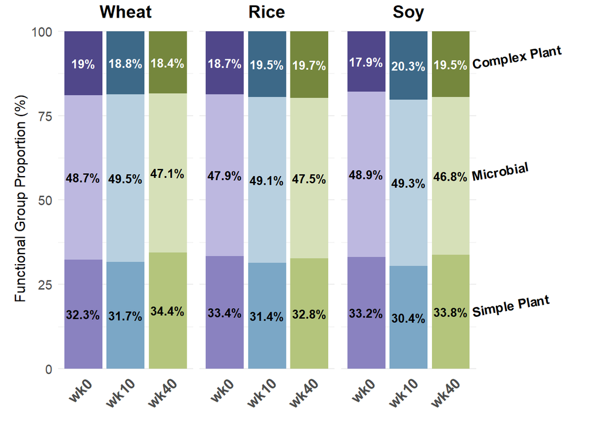

```r
interaction_plot_stacked_no_noPlant <- create_stacked_interaction_plot(
  interaction_stacked_data,
  include_noPlant = FALSE
  )

print(interaction_plot_stacked_no_noPlant)
```

```r
ggsave_themed("stacked_interaction_plot_no_noPlant.png", interaction_plot_stacked_no_noPlant, width = 10, height = 6)
```

# Functional Group Ratios Over Time

These scatterplots show the ratios of organic matter functional groups over the incubation period. Each point represents the mean ratio for a crop at a given timepoint, with error bars showing the standard error. Linear regression lines for each crop are shown with corresponding r² and p-values displayed in each crop’s color.

## Data preparation and regression analysis

This chunk calculates the total plant : microbial ratio (simple + complex) and simple : complex plant ratios for each sample. It then calculates summary statistics (mean and standard error) for these ratios by crop and timepoint. Finally, it performs linear regression for each crop to assess the relationship between timepoint and the ratios, storing the regression statistics (r², p-value, intercept, slope) for later use in plotting.

```r
# Calculate total plant : microbial ratio (simple + complex) for each sample
ftir_data <- ftir_data %>%
  mutate(
    total_plant_prop = simple_plant_prop + complex_plant_prop,
    total_plant_microbial_prop = total_plant_prop / microbial_prop,
    simple_complex_prop = simple_plant_prop / complex_plant_prop
  )

# Create summary statistics by crop and timepoint for ratio metrics
# Convert timepoint to numeric for regression (wk0 = 0, wk10 = 10, etc.)
ratio_stats <- ftir_data %>%
  filter(crop %in% c("wheat", "rice", "soy")) %>%  # Exclude noPlant
  mutate(
    crop = factor(crop, levels = c("wheat", "rice", "soy")),
    timepoint_numeric = as.numeric(str_extract(timepoint, "\\d+"))
  ) %>%
  group_by(crop, timepoint, timepoint_numeric) %>%
  summarise(
    Mean_simple_microbial = mean(simple_microbial_prop, na.rm = TRUE),
    SE_simple_microbial = sd(simple_microbial_prop, na.rm = TRUE) / sqrt(n()),
    Mean_total_microbial = mean(total_plant_microbial_prop, na.rm = TRUE),
    SE_total_microbial = sd(total_plant_microbial_prop, na.rm = TRUE) / sqrt(n()),
    Mean_simple_complex = mean(simple_complex_prop, na.rm = TRUE),
    SE_simple_complex = sd(simple_complex_prop, na.rm = TRUE) / sqrt(n()),
    .groups = 'drop'
  )

# Calculate regression statistics for each crop (simple : microbial ratio)
# Using all individual data points, not just the 3 averaged points
simple_micr_regression_stats <- data.frame()
for (crop_name in c("wheat", "rice", "soy")) {
  crop_data <- ftir_data %>%
    filter(crop == crop_name) %>%
    mutate(timepoint_numeric = as.numeric(str_extract(timepoint, "\\d+")))

  if (nrow(crop_data) > 1) {
    model <- lm(simple_microbial_prop ~ timepoint_numeric, data = crop_data)
    summary_model <- summary(model)

    r_squared <- summary_model$r.squared
    p_value <- summary_model$coefficients[2, 4]
    intercept <- coef(model)[1]
    slope <- coef(model)[2]

    simple_micr_regression_stats <- rbind(simple_micr_regression_stats,
      data.frame(
        crop = crop_name,
        r_squared = r_squared,
        p_value = p_value,
        intercept = intercept,
        slope = slope
      )
    )
  }
}

# Calculate regression statistics for each crop (total plant : microbial ratio)
# Using all individual data points, not just the 3 averaged points
total_micr_regression_stats <- data.frame()
for (crop_name in c("wheat", "rice", "soy")) {
  crop_data <- ftir_data %>%
    filter(crop == crop_name) %>%
    mutate(timepoint_numeric = as.numeric(str_extract(timepoint, "\\d+")))

  if (nrow(crop_data) > 1) {
    model <- lm(total_plant_microbial_prop ~ timepoint_numeric, data = crop_data)
    summary_model <- summary(model)

    r_squared <- summary_model$r.squared
    p_value <- summary_model$coefficients[2, 4]
    intercept <- coef(model)[1]
    slope <- coef(model)[2]

    total_micr_regression_stats <- rbind(total_micr_regression_stats,
      data.frame(
        crop = crop_name,
        r_squared = r_squared,
        p_value = p_value,
        intercept = intercept,
        slope = slope
      )
    )
  }
}

# Calculate regression statistics for each crop (simple plant : complex plant ratio)
# Using all individual data points, not just the 3 averaged points
simple_complex_regression_stats <- data.frame()
for (crop_name in c("wheat", "rice", "soy")) {
  crop_data <- ftir_data %>%
    filter(crop == crop_name) %>%
    mutate(timepoint_numeric = as.numeric(str_extract(timepoint, "\\d+")))

  if (nrow(crop_data) > 1) {
    model <- lm(simple_complex_prop ~ timepoint_numeric, data = crop_data)
    summary_model <- summary(model)

    r_squared <- summary_model$r.squared
    p_value <- summary_model$coefficients[2, 4]
    intercept <- coef(model)[1]
    slope <- coef(model)[2]

    simple_complex_regression_stats <- rbind(simple_complex_regression_stats,
      data.frame(
        crop = crop_name,
        r_squared = r_squared,
        p_value = p_value,
        intercept = intercept,
        slope = slope
      )
    )
  }
}
```

## Ratio scatterplots with regression statistics

This chunk creates scatterplots for the simple : microbial, total plant : microbial, and simple : complex plant ratios over time, with regression lines and statistics displayed for each crop. Significant p-values are indicated with an asterisk (*). The function `create_ratio_scatterplot` is defined to generate these plots, and it is called for each ratio metric.

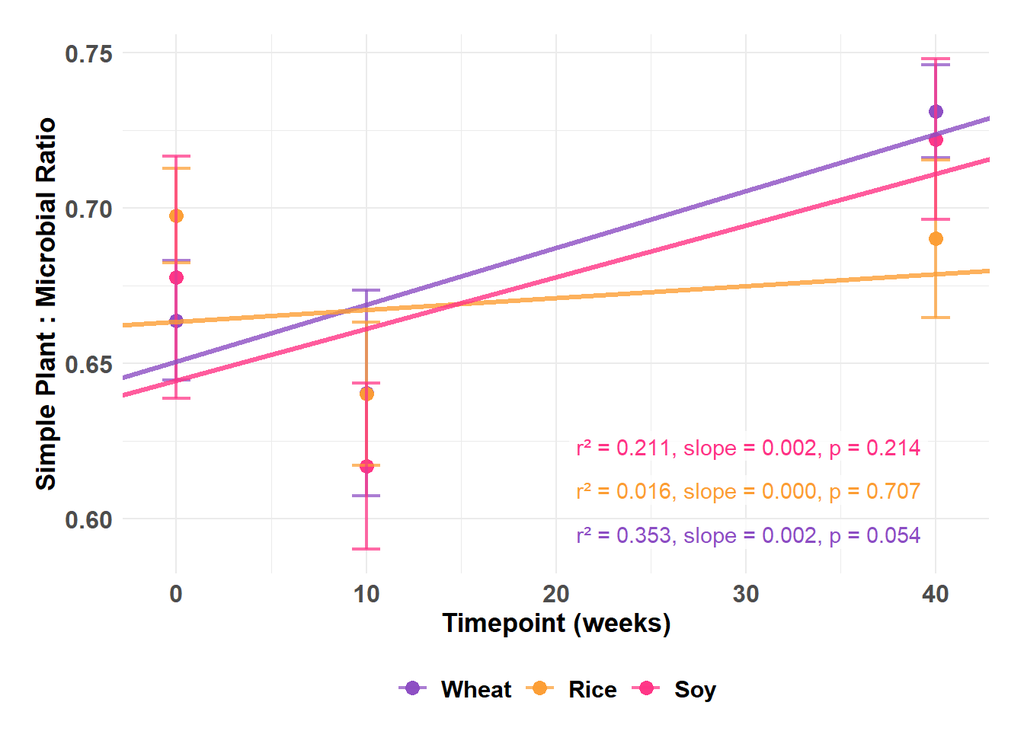

```r
# Function to create ratio scatterplot with regression lines and statistics
create_ratio_scatterplot <- function(data, y_metric, y_metric_se, title, y_label, regression_stats, crop_colors) {
  plot <- ggplot(data, aes(x = timepoint_numeric, y = !!sym(y_metric), color = crop)) +
    geom_point(size = 3, alpha = 0.98) +
    geom_errorbar(aes(ymin = !!sym(y_metric) - !!sym(y_metric_se),
                      ymax = !!sym(y_metric) + !!sym(y_metric_se)),
                  width = 1.5, alpha = 0.73, linewidth = 0.8) +

    scale_color_manual(values = crop_colors, labels = crop_labels) +
    labs(title = title,
         x = "Timepoint (weeks)",
         y = y_label,
         color = "Crop") +
    theme(
      legend.position = "bottom",
      legend.title = element_blank(),
      legend.text = element_text(size = 11.5, face = "bold"),
      axis.text = element_text(size = 12, face = "bold"),
      axis.title = element_text(size = 13, face = "bold"),
      plot.title = element_blank(),
      plot.margin = margin(17, 17, 7, 17)
    )

  # Get data range for positioning. Use the full range INCLUDING error bars (not just
  # the mean points) since that's the actual visible extent of the plot - using only the
  # mean points understated the true y-range and packed the labels too close together.
  max_x <- max(data$timepoint_numeric, na.rm = TRUE)
  min_x <- min(data$timepoint_numeric, na.rm = TRUE)
  max_y <- max(data[[y_metric]] + data[[y_metric_se]], na.rm = TRUE)
  min_y <- min(data[[y_metric]] - data[[y_metric_se]], na.rm = TRUE)
  y_range <- max_y - min_y

  # Create data frame to store all labels
  labels_df <- data.frame(
    label_x = numeric(),
    label_y = numeric(),
    label_text = character(),
    crop_color = character(),
    label_fontface = character(),
    stringsAsFactors = FALSE
  )

  # Add regression lines and statistics for each crop
  for (i in seq_len(nrow(regression_stats))) {
    reg_row <- regression_stats[i, ]
    crop_name <- reg_row$crop
    slope <- reg_row$slope
    intercept <- reg_row$intercept
    r_sq <- reg_row$r_squared
    p_val <- reg_row$p_value
    crop_color <- crop_colors[crop_name]

    # Add regression line
    plot <- plot +
      geom_abline(intercept = intercept, slope = slope,
                  color = crop_color, linewidth = 1.2, alpha = 0.8, linetype = "solid")

    # Position R² and p-value labels at the bottom-right, stacked upward from the
    # bottom of the plot so they stay clear of the data points and don't overlap
    # each other (previously anchored to max_y, which pushed the first label above
    # the plotted range and caused it to overlap the next one down)
    label_x <- min_x + (max_x - min_x) * 0.99
    crop_order <- match(crop_name, c("wheat", "rice", "soy"))
    label_y <- min_y + (y_range * 0.03) + (crop_order - 1) * (y_range * 0.09)

    # Format p-value and determine if significant
    p_significant <- p_val < 0.05
    if (p_val < 0.001) {
      p_label <- "p < 0.001"
    } else {
      p_label <- paste0("p = ", format(round(p_val, 3), nsmall = 3))
    }

    # Add star if p < 0.05 and set formatting
    p_label_with_star <- if (p_significant) paste0(p_label, "*") else p_label
    label_fontface <- if (p_significant) "bold" else "plain"

    # Create label with r², slope, and p-value
    label_text <- paste0("r² = ", format(round(r_sq, 3), nsmall = 3), ", slope = ", format(round(slope, 3), nsmall = 3), ", ", p_label_with_star)

    # Add to labels data frame
    labels_df <- rbind(labels_df, data.frame(
      label_x = label_x,
      label_y = label_y,
      label_text = label_text,
      crop_color = crop_color,
      label_fontface = label_fontface,
      stringsAsFactors = FALSE
    ))
  }

  # Add all labels at once after the loop
  plot <- plot +
    geom_label(data = labels_df,
               aes(x = label_x, y = label_y, label = label_text, color = I(crop_color), fontface = I(label_fontface)),
               fill = annotation_fill_color,
               alpha = 0.77,
               label.size = 0,
               label.color = NA,
               hjust = 1, # Align text to the right
               inherit.aes = FALSE,
               show.legend = FALSE)

  return(plot)
}

# Create Simple Plant : Microbial Ratio scatterplot
simple_micr_plot <- create_ratio_scatterplot(
  data = ratio_stats,
  y_metric = "Mean_simple_microbial",
  y_metric_se = "SE_simple_microbial",
  title = "",
  y_label = "Simple Plant : Microbial Ratio",
  regression_stats = simple_micr_regression_stats,
  crop_colors = crop_colors
)

print(simple_micr_plot)
```

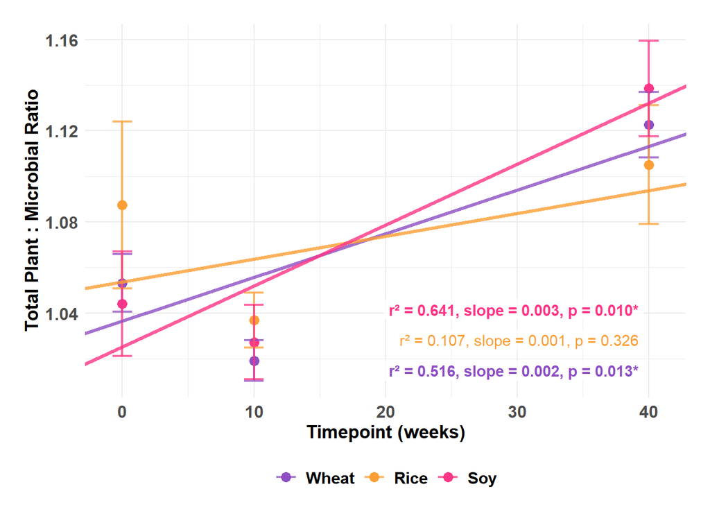

```r
ggsave_themed("simple_plant_microbial_ratio_scatterplot.png", simple_micr_plot)

# Create Total Plant : Microbial Ratio scatterplot
total_micr_plot <- create_ratio_scatterplot(
  data = ratio_stats,
  y_metric = "Mean_total_microbial",
  y_metric_se = "SE_total_microbial",
  title = "",
  y_label = "Total Plant : Microbial Ratio",
  regression_stats = total_micr_regression_stats,
  crop_colors = crop_colors
)

print(total_micr_plot)
```

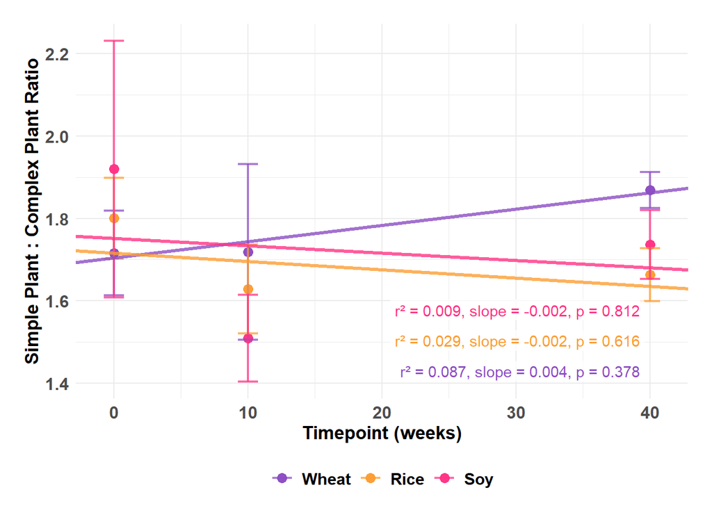

```r
ggsave_themed("total_plant_microbial_ratio_scatterplot.png", total_micr_plot)

# Create Simple Plant : Complex Plant Ratio scatterplot
simple_complex_plot <- create_ratio_scatterplot(
  data = ratio_stats,
  y_metric = "Mean_simple_complex",
  y_metric_se = "SE_simple_complex",
  title = "",
  y_label = "Simple Plant : Complex Plant Ratio",
  regression_stats = simple_complex_regression_stats,
  crop_colors = crop_colors
)

print(simple_complex_plot)
```

```r
ggsave_themed("simple_complex_ratio_scatterplot.png", simple_complex_plot)
```

# Summary

```r
# Print summary information
cat("Summary of FTIR Analysis:\n")
```

```
## Summary of FTIR Analysis:
```

```r
cat("Number of samples:", nrow(ftir_data), "\n")
```

```
## Number of samples: 39
```

```r
cat("Crops:", paste(unique(ftir_data$crop), collapse = ", "), "\n")
```

```
## Crops: wheat, soy, noPlant, rice
```

```r
cat("Timepoints:", paste(unique(ftir_data$timepoint), collapse = ", "), "\n")
```

```
## Timepoints: wk0, wk10, wk30, wk40
```

```r
# Display summary statistics
print("Crop Statistics:")
```

```
## [1] "Crop Statistics:"
```

```r
print(crop_stats)
```

```
## # A tibble: 4 × 7
##   crop    Mean_simple_plant_prop SE_simple_plant_prop Mean_complex_plant_prop
##   <fct>                    <dbl>                <dbl>                   <dbl>
## 1 noPlant                  0.351              0.00709                   0.179
## 2 wheat                    0.327              0.00602                   0.188
## 3 rice                     0.323              0.00547                   0.193
## 4 soy                      0.324              0.00853                   0.192
## # ℹ 3 more variables: SE_complex_plant_prop <dbl>, Mean_microbial_prop <dbl>,
## #   SE_microbial_prop <dbl>
```

```r
print("\nTimepoint Statistics:")
```

```
## [1] "\nTimepoint Statistics:"
```

```r
print(timepoint_stats)
```

```
## # A tibble: 4 × 7
##   timepoint Mean_simple_plant_prop SE_simple_plant_prop Mean_complex_plant_prop
##   <chr>                      <dbl>                <dbl>                   <dbl>
## 1 wk0                        0.328              0.00583                   0.186
## 2 wk10                       0.312              0.00626                   0.195
## 3 wk30                       0.359              0.00197                   0.164
## 4 wk40                       0.341              0.00468                   0.189
## # ℹ 3 more variables: SE_complex_plant_prop <dbl>, Mean_microbial_prop <dbl>,
## #   SE_microbial_prop <dbl>
```

```r
# Check if snv_plusOne exists and what it looks like
dpt_data_rhizo %>%
  filter(wavenumber > 2918 & wavenumber < 2928) %>%
  select(filename, wavenumber, absorbance, baseline_corrected, snv_plusOne) %>%
  group_by(filename) %>%
  summarise(
    n_points = n(),
    min_norm = min(snv_plusOne, na.rm = TRUE),
    max_norm = max(snv_plusOne, na.rm = TRUE),
    mean_norm = mean(snv_plusOne, na.rm = TRUE)
  ) %>%
  head()
```

```
## # A tibble: 6 × 5
##   filename                                  n_points min_norm max_norm mean_norm
##   <chr>                                        <int>    <dbl>    <dbl>     <dbl>
## 1 DRIFTS_Pot001_13Cwheat_wk0_rhizoSoil_260…        8    0.984    1.02      1.01
## 2 DRIFTS_Pot012_13Csoy_wk10_rhizoSoil_2606…        8    0.772    0.830     0.804
## 3 DRIFTS_Pot020_12CnoPlant_wk30_rhizoSoil_…        8    0.972    1.02      0.997
## 4 DRIFTS_Pot020_12CnoPlant_wk40_rhizoSoil_…        8    0.899    0.958     0.931
## 5 DRIFTS_Pot024_13Cwheat_wk0_rhizoSoil_260…        8    0.780    0.829     0.806
## 6 DRIFTS_Pot028_13Cwheat_wk0_rhizoSoil_260…        8    0.828    0.879     0.857
```

# Compare soil & roots

## Import root data and join with soil data

This chunk imports the integrated root data and checks that each pot ID and timepoint combination in the root data has a corresponding entry in the soil data. It then creates a combined dataset including only the crop and timepoint combinations that exist in both datasets, summarizes the data, and counts the number of samples for each crop and timepoint in the combined dataset.

```r
# import root data
root_data_file <- file.path(box_base, "Salk Institute Project/AKS Salk files/Adrianne_FTIRdata/integrated_analysis_outputs/processed_int_data_roots.csv") # WILL NEED TO CHANGE THIS

root_data <- read_csv(root_data_file, show_col_types = FALSE)

# Check that each ID and timepoint combination in the root data has a corresponding entry in the soil data
missing_combinations <- anti_join(root_data, ftir_data, by = c("ID", "timepoint"))
if (nrow(missing_combinations) > 0) {
  warning("The following pot ID and timepoint combinations are present in the root data but missing in the soil data:\n",
          paste(apply(missing_combinations, 1, function(row) paste(row["ID"], row["timepoint"], sep = " - ")), collapse = "\n"))
} else {
  cat("All pot ID and timepoint combinations in the root data have corresponding entries in the soil data.\n")
}

# Create a combined dataset including only the crop and timepoint combinations that exist in both datasets
combined_data <- inner_join(ftir_data, root_data, by = c("ID", "timepoint", "crop"), suffix = c("_soil", "_root")) %>%
  select(-starts_with("type_"), -starts_with("int_"), -starts_with("total_peak_area"), -starts_with("aliphatic_")) %>% # remove unnecessary columns
  mutate(crop_timepoint = paste(crop, timepoint, sep = "_")) # combined crop x timepoint grouping -- matches the keys used in color_map (theme_colors_config.R)
str(combined_data) # check the structure of the combined dataset
```

```
## 'data.frame':    26 obs. of  22 variables:
##  $ sample_soil                    : chr  "DRIFTS_Pot001_13Cwheat_wk0_rhizoSoil_260618.0.dpt" "DRIFTS_Pot012_13Csoy_wk10_rhizoSoil_260624.0.dpt" "DRIFTS_Pot029_13Cwheat_wk10_rhizoSoil_260624.0.dpt" "DRIFTS_Pot029_13Cwheat_wk40_rhizoSoil_260702.0.dpt" ...
##  $ crop                           : chr  "wheat" "soy" "wheat" "wheat" ...
##  $ timepoint                      : chr  "wk0" "wk10" "wk10" "wk40" ...
##  $ ID                             : chr  "001" "012" "029" "029" ...
##  $ simple_plant_prop_soil         : num  0.354 0.282 0.306 0.343 0.32 ...
##  $ complex_plant_prop_soil        : num  0.167 0.217 0.199 0.183 0.203 ...
##  $ microbial_prop_soil            : num  0.479 0.501 0.495 0.473 0.477 ...
##  $ simple_microbial_prop_soil     : num  0.739 0.564 0.617 0.725 0.671 ...
##  $ complex_microbial_prop_soil    : num  0.35 0.433 0.401 0.387 0.426 ...
##  $ total_plant_prop_soil          : num  0.521 0.499 0.505 0.527 0.523 ...
##  $ total_plant_microbial_prop_soil: num  1.089 0.997 1.018 1.112 1.097 ...
##  $ simple_complex_prop_soil       : num  2.11 1.3 1.54 1.88 1.57 ...
##  $ sample_root                    : chr  "DRIFTS_pot001_13Cwheat_wk0_root_250725.0.dpt" "DRIFTS_pot012_13Csoy_wk10_root_250827.0.dpt" "DRIFTS_pot029_13Cwheat_wk10_root_250827.0.dpt" "DRIFTS_pot029_13Cwheat_wk40_root_250827.3.dpt" ...
##  $ simple_plant_prop_root         : num  0.431 0.392 0.427 0.421 0.389 ...
##  $ complex_plant_prop_root        : num  0.186 0.191 0.186 0.206 0.209 ...
##  $ microbial_prop_root            : num  0.383 0.417 0.387 0.373 0.402 ...
##  $ simple_microbial_prop_root     : num  1.125 0.941 1.102 1.13 0.969 ...
##  $ complex_microbial_prop_root    : num  0.484 0.457 0.48 0.554 0.522 ...
##  $ total_plant_prop_root          : num  0.617 0.583 0.613 0.627 0.598 ...
##  $ total_plant_microbial_prop_root: num  1.61 1.4 1.58 1.68 1.49 ...
##  $ simple_complex_prop_root       : num  2.32 2.06 2.3 2.04 1.86 ...
##  $ crop_timepoint                 : chr  "wheat_wk0" "soy_wk10" "wheat_wk10" "wheat_wk40" ...
```

```r
summary(combined_data) # check the summary statistics of the combined dataset
```

```
##  sample_soil            crop            timepoint              ID
##  Length:26          Length:26          Length:26          Length:26
##  Class :character   Class :character   Class :character   Class :character
##  Mode  :character   Mode  :character   Mode  :character   Mode  :character
##
##
##
##  simple_plant_prop_soil complex_plant_prop_soil microbial_prop_soil
##  Min.   :0.2772         Min.   :0.1675          Min.   :0.4630
##  1st Qu.:0.3132         1st Qu.:0.1822          1st Qu.:0.4738
##  Median :0.3272         Median :0.1927          Median :0.4832
##  Mean   :0.3262         Mean   :0.1919          Mean   :0.4819
##  3rd Qu.:0.3433         3rd Qu.:0.1994          3rd Qu.:0.4912
##  Max.   :0.3580         Max.   :0.2219          Max.   :0.5009
##  simple_microbial_prop_soil complex_microbial_prop_soil total_plant_prop_soil
##  Min.   :0.5535             Min.   :0.3498              Min.   :0.4991
##  1st Qu.:0.6409             1st Qu.:0.3854              1st Qu.:0.5088
##  Median :0.6779             Median :0.4013              Median :0.5168
##  Mean   :0.6784             Mean   :0.3980              Mean   :0.5181
##  3rd Qu.:0.7257             3rd Qu.:0.4110              3rd Qu.:0.5262
##  Max.   :0.7722             Max.   :0.4430              Max.   :0.5370
##  total_plant_microbial_prop_soil simple_complex_prop_soil sample_root
##  Min.   :0.9965                  Min.   :1.249            Length:26
##  1st Qu.:1.0359                  1st Qu.:1.577            Class :character
##  Median :1.0697                  Median :1.701            Mode  :character
##  Mean   :1.0764                  Mean   :1.716
##  3rd Qu.:1.1105                  3rd Qu.:1.896
##  Max.   :1.1598                  Max.   :2.122
##  simple_plant_prop_root complex_plant_prop_root microbial_prop_root
##  Min.   :0.3626         Min.   :0.1661          Min.   :0.3498
##  1st Qu.:0.4011         1st Qu.:0.1857          1st Qu.:0.3696
##  Median :0.4233         Median :0.1920          Median :0.3857
##  Mean   :0.4210         Mean   :0.1931          Mean   :0.3859
##  3rd Qu.:0.4378         3rd Qu.:0.2030          3rd Qu.:0.3977
##  Max.   :0.4841         Max.   :0.2163          Max.   :0.4297
##  simple_microbial_prop_root complex_microbial_prop_root total_plant_prop_root
##  Min.   :0.861              Min.   :0.4380              Min.   :0.5703
##  1st Qu.:1.004              1st Qu.:0.4817              1st Qu.:0.6023
##  Median :1.096              Median :0.4986              Median :0.6143
##  Mean   :1.098              Mean   :0.5010              Mean   :0.6141
##  3rd Qu.:1.186              3rd Qu.:0.5220              3rd Qu.:0.6304
##  Max.   :1.384              Max.   :0.5540              Max.   :0.6502
##  total_plant_microbial_prop_root simple_complex_prop_root crop_timepoint
##  Min.   :1.327                   Min.   :1.676            Length:26
##  1st Qu.:1.515                   1st Qu.:1.978            Class :character
##  Median :1.593                   Median :2.228            Mode  :character
##  Mean   :1.599                   Mean   :2.196
##  3rd Qu.:1.705                   3rd Qu.:2.345
##  Max.   :1.859                   Max.   :2.916
```

```r
# save to CSV for reference
write_csv(combined_data, file.path(outputs_folder, "combined_soil_root_data.csv"))
# Count the number of samples for each crop and timepoint in the combined dataset and list the IDs for each group
sample_counts <- combined_data %>%
  group_by(crop, timepoint) %>%
  summarise(n_samples = n(), .groups = 'drop') %>%
  # add list of IDs for each crop and timepoint combination
  left_join(
    combined_data %>%
      group_by(crop, timepoint) %>%
      summarise(sample_IDs = paste(unique(ID), collapse = ", "), .groups = 'drop'),
    by = c("crop", "timepoint")
  )
print(sample_counts) # check the sample counts for each crop and timepoint
```

```
## # A tibble: 11 × 4
##    crop    timepoint n_samples sample_IDs
##    <chr>   <chr>         <int> <chr>
##  1 noPlant wk30              1 052
##  2 noPlant wk40              1 052
##  3 rice    wk0               1 103
##  4 rice    wk10              5 055, 087, 119
##  5 rice    wk40              3 055, 087, 119
##  6 soy     wk0               2 050, 062
##  7 soy     wk10              3 012, 080, 094
##  8 soy     wk40              3 030, 080, 094
##  9 wheat   wk0               2 001, 032
## 10 wheat   wk10              2 029, 053
## 11 wheat   wk40              3 029, 053, 109
```

## Create function to generate scatterplots comparing soil and root proportions

This chunk defines a function that takes “region” as it’s only variable, and generates a scatterplot comparing the soil and root proportions for that region. The function is then called for each of the three regions: simple plant, complex plant, and microbial.

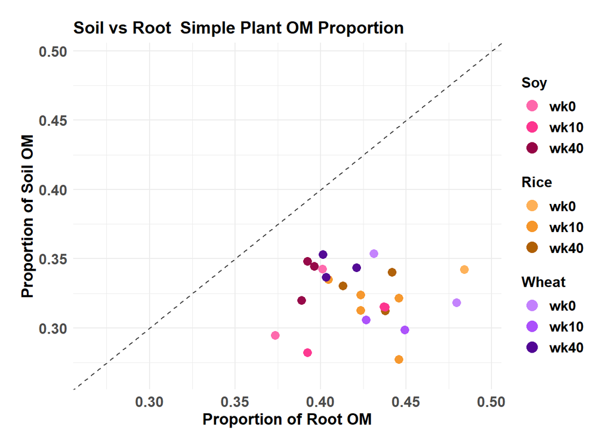

```r
# create a function to generate scatterplots comparing soil and root proportions for a given region
# “region” variable is a proportion to compare (“simple_plant”, “complex_plant”, or “microbial”)
#Function plots all ID-timepoint combinations as points on a scatterplot:
## the x-axis is the root proportion
## the y-axis is the soil proportion
## Points are colored by crop & timepoint as defined by the color_map variable config\theme_colors_config.R

soil_v_root_plot <- function(region, crops_ordered = c("soy", "rice", "wheat")) {
  # Define the column names for soil and root proportions based on the region
  soil_col <- paste0(region, "_prop_soil")
  root_col <- paste0(region, "_prop_root")
  region_label <- str_to_title(gsub("_", " ", region)) # Convert to title case for labeling
    # find the minimum and maximum values for the whole dataset to set the limits of the plot (same for both axes)
  min_val <- min(combined_data[[root_col]], combined_data[[soil_col]], na.rm = TRUE)
  max_val <- max(combined_data[[root_col]], combined_data[[soil_col]], na.rm = TRUE)
  range <- max_val - min_val
  # Assign each point's color directly from its crop's own sub-palette (via crop_timepoint ->
  # color_map lookup), so the real data layer doesn't carry a mapped color aesthetic. This lets
  # us build one legend block per crop (via dummy layers + ggnewscale) the same way
  # build_stacked_range_plot() does, instead of one flat crop_timepoint legend.
  plot_data <- combined_data %>%
    filter(crop != "noPlant") %>%
    mutate(point_color = unname(color_map[as.character(crop_timepoint)])) %>%
    as.data.frame()

  # Create a scatterplot comparing soil and root proportions for the specified region
  # plot <- ggplot(plot_data, aes_string(x = root_col, y = soil_col, color = "crop_timepoint")) +
  #   geom_point(aes(color = I(point_color)), size = 3, alpha = 0.98) +
  plot <- ggplot() +
    geom_point(data = plot_data,
               mapping = aes_string(x = root_col, y = soil_col, color = "point_color"),
               size = 3, alpha = 0.98) +
    scale_color_identity() +

    xlim(min_val - 0.05 * range, max_val + 0.05 * range) +
    ylim(min_val - 0.05 * range, max_val + 0.05 * range) +
    labs(title = paste("Soil vs Root ", region_label, "OM Proportion"),
         x = "Proportion of Root OM",
         y = "Proportion of Soil OM"
         ) +
    theme(
      legend.position = "right",
      legend.direction = "vertical", # lays out timepoint labels within each crop's legend block
      legend.box = "vertical", # lays out the legend blocks
      legend.spacing.y = unit(0.1, "cm"),
      legend.title = element_text(size = 12, face = "bold"),
      legend.text = element_text(size = 11.5, face = "bold"),
      axis.text = element_text(size = 12, face = "bold"),
      axis.title = element_text(size = 13, face = "bold"),
      plot.title = element_text(size = 14, face = "bold"),
      plot.margin = margin(17, 17, 7, 17)
    ) +
    geom_abline(slope = 1, intercept = 0, linetype = "dashed", color = annotation_line_color) # Add a reference line (y=x)
 # Build one legend block per crop using invisible dummy layers + ggnewscale, so each
  # crop keeps its own color palette in its own titled legend block (same approach as
  # build_stacked_range_plot()).
  if (!require(ggnewscale, quietly = TRUE)) {
    install.packages("ggnewscale")
    library(ggnewscale)
  }
  for (i in seq_along(crops_ordered)) {
    crop_name <- crops_ordered[i]
    # Only include timepoints that actually have data for this crop
    present_tps <- names(color_map_all_sep[[crop_name]])[
      names(color_map_all_sep[[crop_name]]) %in% unique(as.character(plot_data$timepoint[plot_data$crop == crop_name]))
    ]
    if (length(present_tps) == 0) next

    dummy_data <- data.frame(
      x = rep(min_val, length(present_tps)),
      y = rep(min_val, length(present_tps)),
      tp = present_tps
    )
    plot <- plot +
      ggnewscale::new_scale_color() +
      geom_point(data = dummy_data, aes(x = x, y = y, color = tp), size = 0, alpha = 0) +
      scale_color_manual(
        name = str_to_title(crop_name),
        values = color_map_all_sep[[crop_name]][present_tps],
        breaks = present_tps,
        labels = present_tps,
        guide = guide_legend(override.aes = list(size = 4, alpha = 1), order = i)
      )
   }
  return(plot)
}
soil_v_root_simple_plot <- soil_v_root_plot("simple_plant")
soil_v_root_complex_plot <- soil_v_root_plot("complex_plant")
soil_v_root_microbial_plot <- soil_v_root_plot("microbial")

print(soil_v_root_simple_plot)
```

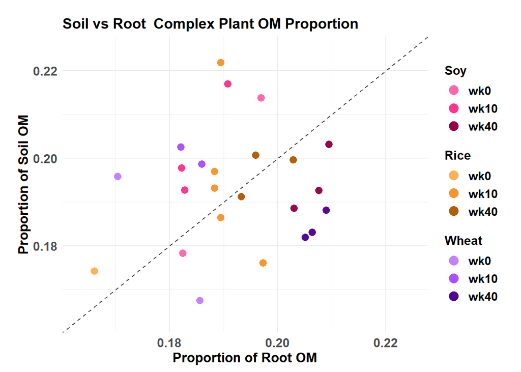

```r
print(soil_v_root_complex_plot)
```

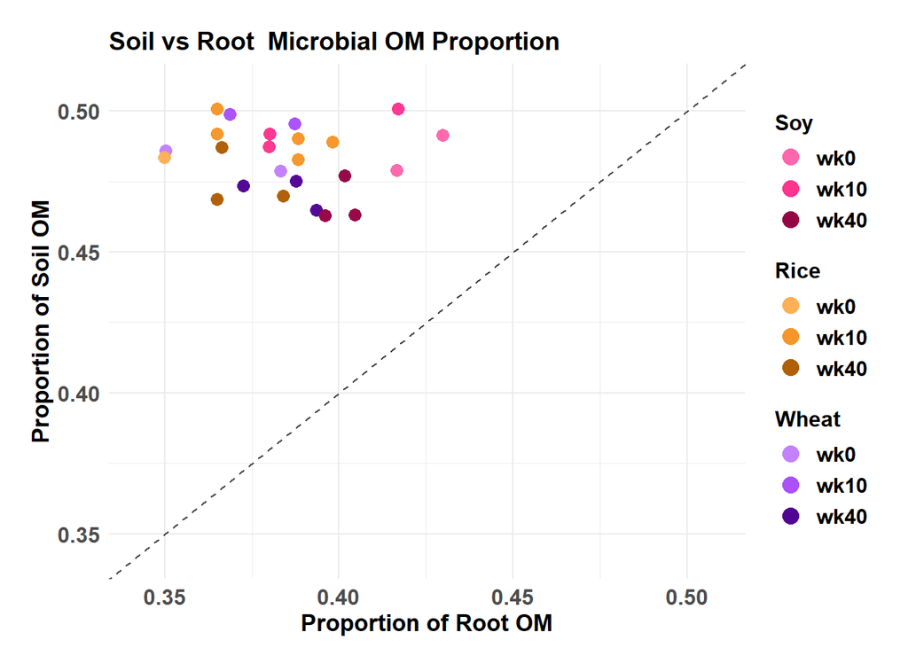

```r
print(soil_v_root_microbial_plot)
```

## Root vs. soil regression statistics

This chunk fits a linear regression of soil proportion on root proportion (`soil ~ root`) for each functional-group region (simple plant, complex plant, microbial), and reports R², slope, and p-value (i) across all data points, (ii) grouped by timepoint, and (iii) grouped by crop.

```r
# Human-readable labels for each functional group region
region_labels <- c(simple_plant = "Simple Plant", complex_plant = "Complex Plant", microbial = "Microbial")

# Helper: fit soil_prop ~ root_prop for a given region, optionally within groups of a
# grouping variable (e.g. "timepoint" or "crop"). Returns R-squared, slope, and p-value.
calc_soil_root_regression <- function(data, region, group_var = NULL) {
  root_col <- paste0(region, "_prop_root")
  soil_col <- paste0(region, "_prop_soil")

  fit_one <- function(df, group_label) {
    df <- df[stats::complete.cases(df[, c(root_col, soil_col)]), ]
    # Need at least 3 points and some spread in x to fit a meaningful regression
    if (nrow(df) < 3 || stats::sd(df[[root_col]]) == 0) {
      return(data.frame(group = group_label, n = nrow(df),
                         r_squared = NA_real_, slope = NA_real_, p_value = NA_real_))
    }
    model <- lm(reformulate(root_col, response = soil_col), data = df)
    model_summary <- summary(model)
    data.frame(
      group = group_label,
      n = nrow(df),
      r_squared = model_summary$r.squared,
      slope = unname(coef(model)[2]),
      p_value = model_summary$coefficients[2, 4]
    )
  }

  if (is.null(group_var)) {
    return(fit_one(data, "All data"))
  }

  groups <- unique(data[[group_var]])
  # Order groups sensibly: timepoints numerically, crops in a fixed order, everything else alphabetically
  if (group_var == "timepoint") {
    groups <- groups[order(as.numeric(str_extract(groups, "\\d+")))]
  } else if (group_var == "crop") {
    crop_order <- c("wheat", "rice", "soy", "noPlant")
    groups <- groups[order(match(groups, crop_order))]
  } else {
    groups <- sort(groups)
  }

  do.call(rbind, lapply(groups, function(g) fit_one(data[data[[group_var]] == g, ], as.character(g))))
}

# Calculate stats for each region: (i) all data, (ii) by timepoint, (iii) by crop
soil_root_regression_stats <- do.call(rbind, lapply(names(region_labels), function(region) {
  stats_region <- rbind(
    calc_soil_root_regression(combined_data, region, group_var = NULL),
    calc_soil_root_regression(combined_data, region, group_var = "timepoint"),
    calc_soil_root_regression(combined_data, region, group_var = "crop")
  )
  stats_region$region <- region_labels[[region]]
  stats_region
}))

# Tidy up for display
soil_root_regression_stats <- soil_root_regression_stats %>%
  select(region, group, n, r_squared, slope, p_value) %>%
  mutate(
    r_squared = round(r_squared, 3),
    slope = round(slope, 3),
    p_value = case_when(
      is.na(p_value) ~ NA_character_,
      p_value < 0.001 ~ "< 0.001",
      TRUE ~ format(round(p_value, 3), nsmall = 3)
    )
  )

knitr::kable(soil_root_regression_stats,
             col.names = c("Region", "Group", "n", "R\u00b2", "Slope", "p-value"),
             row.names = FALSE)
```

| Region | Group | n | R² | Slope | p-value |
| --- | --- | --- | --- | --- | --- |
| Simple Plant | All data | 26 | 0.023 | -0.117 | 0.461 |
| Simple Plant | wk0 | 5 | 0.143 | 0.186 | 0.531 |
| Simple Plant | wk10 | 10 | 0.003 | -0.058 | 0.871 |
| Simple Plant | wk30 | 1 | NA | NA | NA |
| Simple Plant | wk40 | 10 | 0.005 | -0.055 | 0.839 |
| Simple Plant | wheat | 7 | 0.308 | -0.459 | 0.196 |
| Simple Plant | rice | 9 | 0.001 | 0.027 | 0.935 |
| Simple Plant | soy | 8 | 0.006 | 0.083 | 0.851 |
| Simple Plant | noPlant | 2 | NA | NA | NA |
| Complex Plant | All data | 26 | 0.005 | -0.079 | 0.737 |
| Complex Plant | wk0 | 5 | 0.202 | 0.684 | 0.448 |
| Complex Plant | wk10 | 10 | 0.057 | -0.685 | 0.506 |
| Complex Plant | wk30 | 1 | NA | NA | NA |
| Complex Plant | wk40 | 10 | 0.015 | 0.169 | 0.739 |
| Complex Plant | wheat | 7 | 0.137 | -0.302 | 0.413 |
| Complex Plant | rice | 9 | 0.134 | 0.511 | 0.332 |
| Complex Plant | soy | 8 | 0.035 | 0.211 | 0.657 |
| Complex Plant | noPlant | 2 | NA | NA | NA |
| Microbial | All data | 26 | 0.009 | -0.053 | 0.647 |
| Microbial | wk0 | 5 | 0.033 | 0.026 | 0.770 |
| Microbial | wk10 | 10 | 0.002 | -0.018 | 0.894 |
| Microbial | wk30 | 1 | NA | NA | NA |
| Microbial | wk40 | 10 | 0.138 | -0.197 | 0.291 |
| Microbial | wheat | 7 | 0.160 | -0.329 | 0.373 |
| Microbial | rice | 9 | 0.001 | -0.024 | 0.925 |
| Microbial | soy | 8 | 0.019 | 0.107 | 0.745 |
| Microbial | noPlant | 2 | NA | NA | NA |

# Root vs. soil: percent change (wk10 -> wk40, within-pot)

Since pot IDs are tracked longitudinally starting at wk10 (wk0 pots were destroyed and not resampled), this section calculates a within-pot percent change from wk10 to wk40, instead of comparing against a crop-level baseline. Each pot’s own wk10 measurement is the denominator, for both root and soil, so the two are directly comparable and the pairing is exact (same physical pot at both timepoints).

## Calculate within-pot percent change (wk10 -> wk40)

```r
regions <- c("simple_plant", "complex_plant", "microbial")
root_cols <- paste0(regions, "_prop_root")
soil_cols <- paste0(regions, "_prop_soil")

wk10_vals <- combined_data %>%
  filter(timepoint == "wk10") %>%
  filter(!sample_soil %in% c("DRIFTS_Pot055_13Crice_wk10_rhizoSoil_260624A.0.dpt", "DRIFTS_Pot119_13Crice_wk10_rhizoSoil_260624B.0.dpt")) %>% # filter out rice duplicates
  select(crop, ID, all_of(c(root_cols, soil_cols))) %>%
  rename_with(~ paste0(.x, "_wk10"), all_of(c(root_cols, soil_cols)))

wk40_vals <- combined_data %>%
  filter(timepoint == "wk40") %>%
  select(crop, ID, all_of(c(root_cols, soil_cols))) %>%
  rename_with(~ paste0(.x, "_wk40"), all_of(c(root_cols, soil_cols)))

# Check that each pot ID present at one timepoint is also present at the other
missing_wk40 <- anti_join(wk10_vals, wk40_vals, by = c("crop", "ID"))
missing_wk10 <- anti_join(wk40_vals, wk10_vals, by = c("crop", "ID"))

if (nrow(missing_wk40) > 0) {
  cat("Pot IDs with wk10 data but no matching wk40 data (excluded from within-pot comparison):\n")
  print(as.data.frame(missing_wk40 %>% select(crop, ID)))
}
```

```
## Pot IDs with wk10 data but no matching wk40 data (excluded from within-pot comparison):
##   crop  ID
## 1  soy 012
```

```r
if (nrow(missing_wk10) > 0) {
  cat("Pot IDs with wk40 data but no matching wk10 data (excluded from within-pot comparison):\n")
  print(as.data.frame(missing_wk10 %>% select(crop, ID)))
}
```

```
## Pot IDs with wk40 data but no matching wk10 data (excluded from within-pot comparison):
##      crop  ID
## 1     soy 030
## 2 noPlant 052
## 3   wheat 109
```

```r
# Pair each pot ID's wk10 and wk40 measurements -- true within-pot comparison
change_data_wk10_wk40 <- inner_join(wk10_vals, wk40_vals, by = c("crop", "ID"))

for (region in regions) {
  root_wk10 <- paste0(region, "_prop_root_wk10")
  root_wk40 <- paste0(region, "_prop_root_wk40")
  soil_wk10 <- paste0(region, "_prop_soil_wk10")
  soil_wk40 <- paste0(region, "_prop_soil_wk40")

  change_data_wk10_wk40[[paste0(region, "_root_pct_change")]] <-
    (change_data_wk10_wk40[[root_wk40]] - change_data_wk10_wk40[[root_wk10]]) / change_data_wk10_wk40[[root_wk10]] * 100
  change_data_wk10_wk40[[paste0(region, "_soil_pct_change")]] <-
    (change_data_wk10_wk40[[soil_wk40]] - change_data_wk10_wk40[[soil_wk10]]) / change_data_wk10_wk40[[soil_wk10]] * 100
}

change_data_wk10_wk40 <- change_data_wk10_wk40 %>%
  select(crop, ID, ends_with("_pct_change"))

cat("\nWithin-pot wk10 -> wk40 change dataset:", nrow(change_data_wk10_wk40), "pots\n")
```

```
##
## Within-pot wk10 -> wk40 change dataset: 7 pots
```

```r
str(change_data_wk10_wk40)
```

```
## 'data.frame':    7 obs. of  8 variables:
##  $ crop                         : chr  "wheat" "wheat" "rice" "soy" ...
##  $ ID                           : chr  "029" "053" "055" "080" ...
##  $ simple_plant_root_pct_change : num  -1.31 -10.64 3.39 -9.49 2.11 ...
##  $ simple_plant_soil_pct_change : num  12.294 18.279 -0.138 9.351 -1.333 ...
##  $ complex_plant_root_pct_change: num  11 12.63 4.02 13.94 2.84 ...
##  $ complex_plant_soil_pct_change: num  -7.82 -10.17 1.86 -2.63 13.4 ...
##  $ microbial_root_pct_change    : num  -3.83 6.73 -5.65 4.25 -3.55 ...
##  $ microbial_soil_pct_change    : num  -4.45 -6.81 -0.66 -4.98 -3.91 ...
```

```r
summary(change_data_wk10_wk40)
```

```
##      crop                ID            simple_plant_root_pct_change
##  Length:7           Length:7           Min.   :-10.6383
##  Class :character   Class :character   1st Qu.: -9.8532
##  Mode  :character   Mode  :character   Median : -1.3134
##                                        Mean   : -3.8588
##                                        3rd Qu.:  0.6269
##                                        Max.   :  3.3926
##  simple_plant_soil_pct_change complex_plant_root_pct_change
##  Min.   :-1.333               Min.   : 2.007
##  1st Qu.: 2.815               1st Qu.: 3.431
##  Median : 9.351               Median :11.005
##  Mean   : 7.813               Mean   : 8.215
##  3rd Qu.:11.382               3rd Qu.:11.847
##  Max.   :18.279               Max.   :13.937
##  complex_plant_soil_pct_change microbial_root_pct_change
##  Min.   :-10.1665              Min.   :-5.649774
##  1st Qu.: -5.2252              1st Qu.:-3.693926
##  Median : -2.1760              Median : 0.008839
##  Mean   : -0.7087              Mean   : 0.624972
##  3rd Qu.:  2.2150              3rd Qu.: 5.338455
##  Max.   : 13.4018              Max.   : 6.726683
##  microbial_soil_pct_change
##  Min.   :-6.8103
##  1st Qu.:-5.4174
##  Median :-4.7435
##  Mean   :-4.4877
##  3rd Qu.:-4.1827
##  Max.   :-0.6601
```

```r
# save as CSV for reference
write_csv(change_data_wk10_wk40, file.path(outputs_folder, "within_pot_change_data_wk10_wk40.csv"))
```

## Create function to generate within-pot percent-change scatterplots

Plots showing the change in each OM-proportion as a percentage difference from wk10 to wk40. Each point is one pot’s own wk10 -> wk40 change (true pairing, not a crop average). Dashed reference line shows a slope of -1 (proportional relationship). Wheat and soy roots decrease in simple plant OM proportion, while the adjacent rhizosphere soil increases in simple plant OM proportion, suggesting that the decomposing roots are contributing simple aliphatics to the soil OM pool.

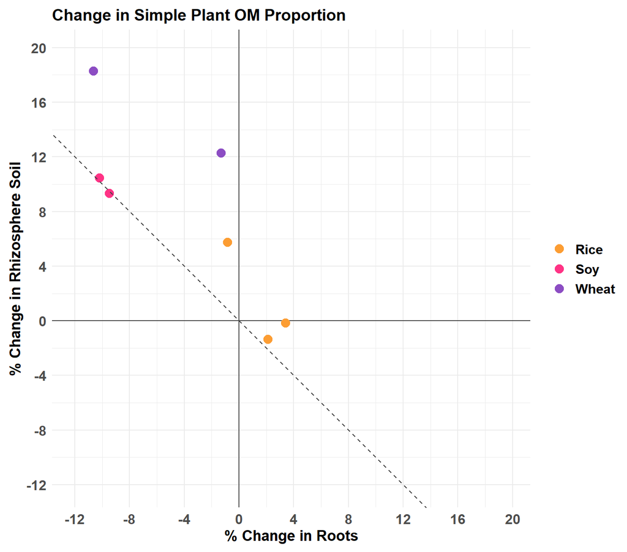

```r
print_square_plot <- function(plot, panel_size = unit(5.8, "in")) {
  fixed_plot <- egg::set_panel_size(plot, width = panel_size, height = panel_size)
  grid::grid.newpage()
  grid::grid.draw(fixed_plot)
}
soil_v_root_change_plot_wk10_wk40 <- function(region) {
  root_col <- paste0(region, "_root_pct_change")
  soil_col <- paste0(region, "_soil_pct_change")
  # find the minimum and maximum values for the whole dataset to set the limits of the plot
  min_val <- min(change_data_wk10_wk40[[root_col]], change_data_wk10_wk40[[soil_col]], na.rm = TRUE)
  max_val <- max(change_data_wk10_wk40[[root_col]], change_data_wk10_wk40[[soil_col]], na.rm = TRUE)
  range <- max_val - min_val
  lower <- min_val - 0.05 * range
  upper <- max_val + 0.05 * range
  step <- max(round(0.15 * range, 0), 1)  # 15% of the rangeor some sensible minimum
  breaks <- seq(
  from = step * floor(lower / step),
  to   = step * ceiling(upper / step),
  by   = step
)


  plot <- ggplot(change_data_wk10_wk40, aes_string(x = root_col, y = soil_col, color = "crop")) +
    geom_hline(yintercept = 0, linetype = "solid", color = annotation_line_color) +
    geom_vline(xintercept = 0, linetype = "solid", color = annotation_line_color) +
    geom_point(size = 3.3, alpha = 1) +
    scale_color_manual(values = crop_colors, labels = crop_labels) +
    # set the limits of the plot to be slightly larger than the min and max values to avoid cutting off points at the edges
    scale_x_continuous(limits = c(lower, upper), breaks = breaks) +
    scale_y_continuous(limits = c(lower, upper), breaks = breaks) +
    labs(title = paste("Change in", str_to_title(gsub("_", " ", region)), "OM Proportion"),
         x = "% Change in Roots",
         y = "% Change in Rhizosphere Soil") +
    theme(
      legend.position = "right",
      legend.title = element_blank(),
      legend.text = element_text(size = 11.5, face = "bold"),
      axis.text = element_text(size = 12, face = "bold"),
      axis.title = element_text(size = 13, face = "bold"),
      plot.title = element_text(size = 14, face = "bold"),
      plot.margin = margin(l = 10, t = 7, r = 7, b = 7),
      aspect.ratio = 1  # Ensure equal scaling for x and y axes
    ) +
    geom_abline(slope = -1, intercept = 0, linetype = "dashed", color = annotation_line_color) # Add a reference line (y=-x)
  ggsave(
    file.path(outputs_folder, sub("\\.png$", paste0(theme_suffix, ".png"),
    paste0(region, "_change_plot_wk10_wk40.png"))),
    plot
    )

  return(plot)
}

soil_v_root_change_wk10_wk40_simple_plot    <- soil_v_root_change_plot_wk10_wk40("simple_plant")
soil_v_root_change_wk10_wk40_complex_plot   <- soil_v_root_change_plot_wk10_wk40("complex_plant")
soil_v_root_change_wk10_wk40_microbial_plot <- soil_v_root_change_plot_wk10_wk40("microbial")

print_square_plot(soil_v_root_change_wk10_wk40_simple_plot)
```

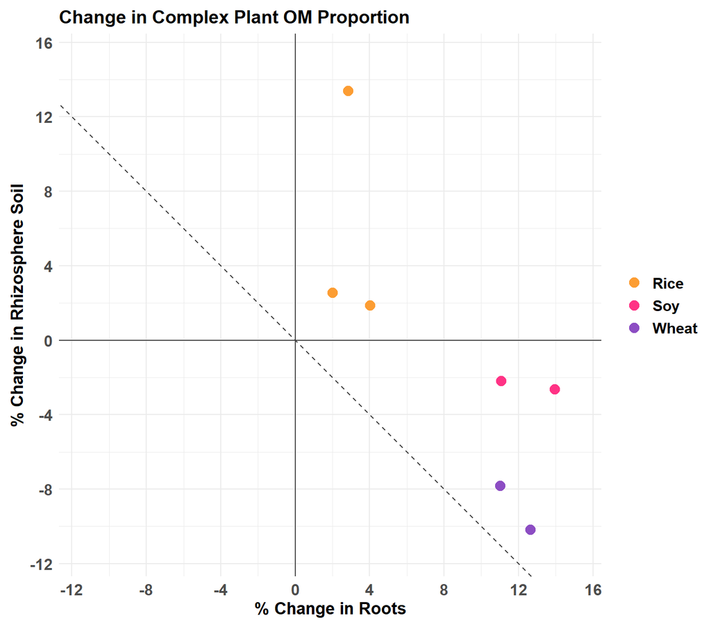

```r
print_square_plot(soil_v_root_change_wk10_wk40_complex_plot)
```

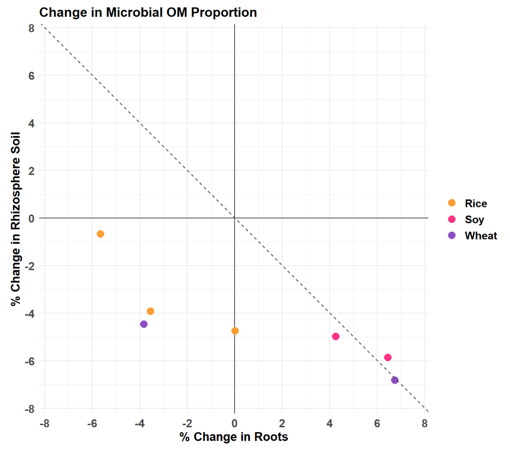

```r
print_square_plot(soil_v_root_change_wk10_wk40_microbial_plot)
```

## Within-pot percent change regression statistics

Since this data is a true within-pot pairing (not a crop average), the root vs. soil regression is meaningful here. This chunk fits `soil_pct_change ~ root_pct_change` for each region, (i) across all pots and (ii) grouped by crop. (There’s no “by timepoint” grouping this time, since wk10 -> wk40 is a single fixed period rather than multiple timepoints.)

```r
# Generic helper: fit y_col ~ x_col, optionally within groups of group_var.
# Returns n, R-squared, slope, and p-value for each group (or one row if group_var is NULL).
calc_regression_stats <- function(data, x_col, y_col, group_var = NULL) {
  fit_one <- function(df, group_label) {
    df <- df[stats::complete.cases(df[, c(x_col, y_col)]), ]
    if (nrow(df) < 3 || stats::sd(df[[x_col]]) == 0) {
      return(data.frame(group = group_label, n = nrow(df),
                         r_squared = NA_real_, slope = NA_real_, p_value = NA_real_))
    }
    model <- lm(reformulate(x_col, response = y_col), data = df)
    model_summary <- summary(model)
    data.frame(
      group = group_label,
      n = nrow(df),
      r_squared = model_summary$r.squared,
      slope = unname(coef(model)[2]),
      p_value = model_summary$coefficients[2, 4]
    )
  }

  if (is.null(group_var)) {
    return(fit_one(data, "All data"))
  }

  groups <- unique(data[[group_var]])
  if (group_var == "crop") {
    crop_order <- c("wheat", "rice", "soy", "noPlant")
    groups <- groups[order(match(groups, crop_order))]
  } else {
    groups <- sort(groups)
  }

  do.call(rbind, lapply(groups, function(g) fit_one(data[data[[group_var]] == g, ], as.character(g))))
}

region_labels <- c(simple_plant = "Simple Plant", complex_plant = "Complex Plant", microbial = "Microbial")

# Calculate stats for each region: (i) all pots, (ii) by crop
change_regression_stats_wk10_wk40 <- do.call(rbind, lapply(names(region_labels), function(region) {
  x_col <- paste0(region, "_root_pct_change")
  y_col <- paste0(region, "_soil_pct_change")

  stats_region <- rbind(
    calc_regression_stats(change_data_wk10_wk40, x_col, y_col, group_var = NULL),
    calc_regression_stats(change_data_wk10_wk40, x_col, y_col, group_var = "crop")
  )
  stats_region$region <- region_labels[[region]]
  stats_region
}))

# Tidy up for display
change_regression_stats_wk10_wk40 <- change_regression_stats_wk10_wk40 %>%
  select(region, group, n, r_squared, slope, p_value) %>%
  mutate(
    r_squared = round(r_squared, 3),
    slope = round(slope, 3),
    p_value = case_when(
      is.na(p_value) ~ NA_character_,
      p_value < 0.001 ~ "< 0.001",
      TRUE ~ format(round(p_value, 3), nsmall = 3)
    )
  )

knitr::kable(change_regression_stats_wk10_wk40,
             col.names = c("Region", "Group", "n", "R\u00b2", "Slope", "p-value"),
             row.names = FALSE)
```

| Region | Group | n | R² | Slope | p-value |
| --- | --- | --- | --- | --- | --- |
| Simple Plant | All data | 7 | 0.644 | -0.918 | 0.030 |
| Simple Plant | wheat | 2 | NA | NA | NA |
| Simple Plant | rice | 3 | 0.807 | -1.565 | 0.290 |
| Simple Plant | soy | 2 | NA | NA | NA |
| Complex Plant | All data | 7 | 0.609 | -1.200 | 0.039 |
| Complex Plant | wheat | 2 | NA | NA | NA |
| Complex Plant | rice | 3 | 0.024 | -0.995 | 0.900 |
| Complex Plant | soy | 2 | NA | NA | NA |
| Microbial | All data | 7 | 0.696 | -0.312 | 0.020 |
| Microbial | wheat | 2 | NA | NA | NA |
| Microbial | rice | 3 | 0.788 | -0.670 | 0.304 |
| Microbial | soy | 2 | NA | NA | NA |

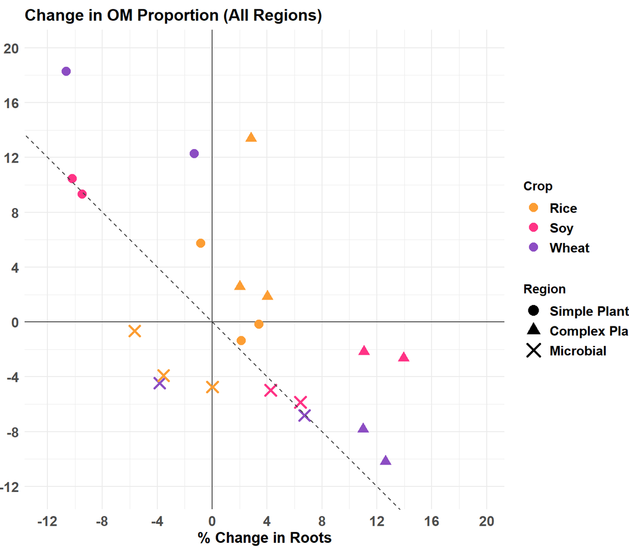

```r
# Build the long-format dataset directly (no pivot_wider needed, avoids list-column
# issues if any crop+ID combination isn't perfectly unique going in)
change_data_long <- bind_rows(
  change_data_wk10_wk40 %>%
    transmute(crop, ID, region = "Simple Plant",
              root = simple_plant_root_pct_change,
              soil = simple_plant_soil_pct_change),
  change_data_wk10_wk40 %>%
    transmute(crop, ID, region = "Complex Plant",
              root = complex_plant_root_pct_change,
              soil = complex_plant_soil_pct_change),
  change_data_wk10_wk40 %>%
    transmute(crop, ID, region = "Microbial",
              root = microbial_root_pct_change,
              soil = microbial_soil_pct_change)
) %>%
  mutate(region = factor(region, levels = c("Simple Plant", "Complex Plant", "Microbial")))

soil_v_root_change_plot_combined_wk10_wk40 <- function(data) {
  min_val <- min(data$root, data$soil, na.rm = TRUE)
  max_val <- max(data$root, data$soil, na.rm = TRUE)
  range <- max_val - min_val
  lower <- min_val - 0.05 * range
  upper <- max_val + 0.05 * range
  step <- max(round(0.15 * range, 0), 1)
  breaks <- seq(
    from = step * floor(lower / step),
    to   = step * ceiling(upper / step),
    by   = step
  )

  region_shapes <- c("Simple Plant" = 16, "Complex Plant" = 17, "Microbial" = 4)
  region_strokes <- c("Simple Plant" = 0.5, "Complex Plant" = 0.5, "Microbial" = 1.5)

  plot <- ggplot(data, aes(x = root, y = soil, color = crop, shape = region, stroke = region)) +
    geom_hline(yintercept = 0, linetype = "solid", color = annotation_line_color) +
    geom_vline(xintercept = 0, linetype = "solid", color = annotation_line_color) +
    geom_point(size = 3.3, alpha = 1) +
    scale_color_manual(values = crop_colors, labels = crop_labels) +
    scale_shape_manual(
      values = region_shapes,
      guide = guide_legend(title = "Region", override.aes = list(color = annotation_text_color, size = 4))
      ) +
      scale_discrete_manual(
        aesthetics = "stroke",
        values = region_strokes,
        guide = guide_legend(title = "Region")
        ) +
    scale_x_continuous(limits = c(lower, upper), breaks = breaks) +
    scale_y_continuous(limits = c(lower, upper), breaks = breaks) +
    labs(title = "Change in OM Proportion (All Regions)",
         x = "% Change in Roots",
         y = "% Change in Rhizosphere Soil",
         color = "Crop"
         ) +
    theme(
      legend.position = "right",
      legend.title = element_text(face = "bold"),
      legend.text = element_text(size = 11.5, face = "bold"),
      axis.text = element_text(size = 12, face = "bold"),
      axis.title = element_text(size = 13, face = "bold"),
      plot.title = element_text(size = 14, face = "bold"),
      aspect.ratio = 1
    ) +
    geom_abline(slope = -1, intercept = 0, linetype = "dashed", color = annotation_line_color)

  ggsave(
    file.path(outputs_folder, paste0("combined_regions_change_plot_wk10_wk40", theme_suffix, ".png")),
    plot, width = 7.6, height = 6.7
  )

  return(plot)
}

combined_change_plot_wk10_wk40 <- soil_v_root_change_plot_combined_wk10_wk40(change_data_long)
print_square_plot(combined_change_plot_wk10_wk40)
```